# Prediction On Resale Flat Price

References:

1. https://statsandr.com/blog/descriptive-statistics-in-r/  
2. https://towardsdatascience.com/data-cleaning-with-r-and-the-tidyverse-detecting-missing-values-ea23c519bc62  
3. https://rstudio-pubs-static.s3.amazonaws.com/3364_d1a578f521174152b46b19d0c83cbe7e.html  
4. https://medium.com/data-science-in-your-pocket/various-data-distributions-in-statistics-362dc92558db  
5. https://stackoverflow.com/questions/5570293/add-column-which-contains-binned-values-of-an-integer-column

## Import Libraries

```r
library(tidyr)
library(tidyverse)
library(summarytools)
library(car)
library(dlookr)
```

```r
library(ggplot2)
```

# Data Cleaning

## Read CSV

```r
data_2015_2016 <- read.csv("../data/resale-flat-prices-based-on-registration-date-from-jan-2015-to-dec-2016.csv", header = TRUE, sep = ",")
data_2017 <- read.csv("../data/resale-flat-prices-based-on-registration-date-from-jan-2017-onwards.csv", header = TRUE, sep = ",")
```

## Data Columns Exploration

```r
print("data_2015_2016:")
```

```
## [1] "data_2015_2016:"
```

```r
str(data_2015_2016)
```

```
## 'data.frame':    37153 obs. of  11 variables:
##  $ month              : chr  "2015-01" "2015-01" "2015-01" "2015-01" ...
##  $ town               : chr  "ANG MO KIO" "ANG MO KIO" "ANG MO KIO" "ANG MO KIO" ...
##  $ flat_type          : chr  "3 ROOM" "3 ROOM" "3 ROOM" "3 ROOM" ...
##  $ block              : chr  "174" "541" "163" "446" ...
##  $ street_name        : chr  "ANG MO KIO AVE 4" "ANG MO KIO AVE 10" "ANG MO KIO AVE 4" "ANG MO KIO AVE 10" ...
##  $ storey_range       : chr  "07 TO 09" "01 TO 03" "01 TO 03" "01 TO 03" ...
##  $ floor_area_sqm     : num  60 68 69 68 68 67 68 68 67 68 ...
##  $ flat_model         : chr  "Improved" "New Generation" "New Generation" "New Generation" ...
##  $ lease_commence_date: int  1986 1981 1980 1979 1980 1980 1980 1981 1978 1985 ...
##  $ remaining_lease    : int  70 65 64 63 64 64 64 65 62 69 ...
##  $ resale_price       : num  255000 275000 285000 290000 290000 ...
```

```r
print("data_2017:")
```

```
## [1] "data_2017:"
```

```r
str(data_2017)
```

```
## 'data.frame':    115302 obs. of  11 variables:
##  $ month              : chr  "2017-01" "2017-01" "2017-01" "2017-01" ...
##  $ town               : chr  "ANG MO KIO" "ANG MO KIO" "ANG MO KIO" "ANG MO KIO" ...
##  $ flat_type          : chr  "2 ROOM" "3 ROOM" "3 ROOM" "3 ROOM" ...
##  $ block              : chr  "406" "108" "602" "465" ...
##  $ street_name        : chr  "ANG MO KIO AVE 10" "ANG MO KIO AVE 4" "ANG MO KIO AVE 5" "ANG MO KIO AVE 10" ...
##  $ storey_range       : chr  "10 TO 12" "01 TO 03" "01 TO 03" "04 TO 06" ...
##  $ floor_area_sqm     : num  44 67 67 68 67 68 68 67 68 67 ...
##  $ flat_model         : chr  "Improved" "New Generation" "New Generation" "New Generation" ...
##  $ lease_commence_date: int  1979 1978 1980 1980 1980 1981 1979 1976 1979 1979 ...
##  $ remaining_lease    : chr  "61 years 04 months" "60 years 07 months" "62 years 05 months" "62 years 01 month" ...
##  $ resale_price       : num  232000 250000 262000 265000 265000 275000 280000 285000 285000 285000 ...
```

## Data Integration

```r
data <- rbind(data_2015_2016, data_2017)
str(data)
```

```
## 'data.frame':    152455 obs. of  11 variables:
##  $ month              : chr  "2015-01" "2015-01" "2015-01" "2015-01" ...
##  $ town               : chr  "ANG MO KIO" "ANG MO KIO" "ANG MO KIO" "ANG MO KIO" ...
##  $ flat_type          : chr  "3 ROOM" "3 ROOM" "3 ROOM" "3 ROOM" ...
##  $ block              : chr  "174" "541" "163" "446" ...
##  $ street_name        : chr  "ANG MO KIO AVE 4" "ANG MO KIO AVE 10" "ANG MO KIO AVE 4" "ANG MO KIO AVE 10" ...
##  $ storey_range       : chr  "07 TO 09" "01 TO 03" "01 TO 03" "01 TO 03" ...
##  $ floor_area_sqm     : num  60 68 69 68 68 67 68 68 67 68 ...
##  $ flat_model         : chr  "Improved" "New Generation" "New Generation" "New Generation" ...
##  $ lease_commence_date: int  1986 1981 1980 1979 1980 1980 1980 1981 1978 1985 ...
##  $ remaining_lease    : chr  "70" "65" "64" "63" ...
##  $ resale_price       : num  255000 275000 285000 290000 290000 ...
```

The merged dataset contains total 152,455 observations (flat resales transaction) and 11 variables.

## Data Exploration To Detect Incorrect Data, Handling Incorrect Data, and Transforming Data

```r
summary(data)
```

```
##     month               town            flat_type            block
##  Length:152455      Length:152455      Length:152455      Length:152455
##  Class :character   Class :character   Class :character   Class :character
##  Mode  :character   Mode  :character   Mode  :character   Mode  :character
##
##
##
##  street_name        storey_range       floor_area_sqm    flat_model
##  Length:152455      Length:152455      Min.   : 31.00   Length:152455
##  Class :character   Class :character   1st Qu.: 82.00   Class :character
##  Mode  :character   Mode  :character   Median : 95.00   Mode  :character
##                                        Mean   : 97.65
##                                        3rd Qu.:113.00
##                                        Max.   :280.00
##  lease_commence_date remaining_lease     resale_price
##  Min.   :1966        Length:152455      Min.   : 140000
##  1st Qu.:1984        Class :character   1st Qu.: 343000
##  Median :1993        Mode  :character   Median : 420888
##  Mean   :1994                           Mean   : 453455
##  3rd Qu.:2003                           3rd Qu.: 530000
##  Max.   :2019                           Max.   :1360000
```

```r
head(data)
```

```
##     month       town flat_type block       street_name storey_range
## 1 2015-01 ANG MO KIO    3 ROOM   174  ANG MO KIO AVE 4     07 TO 09
## 2 2015-01 ANG MO KIO    3 ROOM   541 ANG MO KIO AVE 10     01 TO 03
## 3 2015-01 ANG MO KIO    3 ROOM   163  ANG MO KIO AVE 4     01 TO 03
## 4 2015-01 ANG MO KIO    3 ROOM   446 ANG MO KIO AVE 10     01 TO 03
## 5 2015-01 ANG MO KIO    3 ROOM   557 ANG MO KIO AVE 10     07 TO 09
## 6 2015-01 ANG MO KIO    3 ROOM   603  ANG MO KIO AVE 5     07 TO 09
##   floor_area_sqm     flat_model lease_commence_date remaining_lease
## 1             60       Improved                1986              70
## 2             68 New Generation                1981              65
## 3             69 New Generation                1980              64
## 4             68 New Generation                1979              63
## 5             68 New Generation                1980              64
## 6             67 New Generation                1980              64
##   resale_price
## 1       255000
## 2       275000
## 3       285000
## 4       290000
## 5       290000
## 6       290000
```

```r
tail(data)
```

```
##          month   town        flat_type block  street_name storey_range
## 152450 2021-12 YISHUN        EXECUTIVE   824 YISHUN ST 81     04 TO 06
## 152451 2021-01 YISHUN MULTI-GENERATION   666 YISHUN AVE 4     10 TO 12
## 152452 2021-11 YISHUN MULTI-GENERATION   666 YISHUN AVE 4     07 TO 09
## 152453 2021-03 YISHUN MULTI-GENERATION   633 YISHUN ST 61     10 TO 12
## 152454 2021-10 YISHUN MULTI-GENERATION   632 YISHUN ST 61     01 TO 03
## 152455 2021-12 YISHUN MULTI-GENERATION   633 YISHUN ST 61     07 TO 09
##        floor_area_sqm       flat_model lease_commence_date    remaining_lease
## 152450            146       Maisonette                1987           65 years
## 152451            179 Multi Generation                1987           66 years
## 152452            164 Multi Generation                1987  65 years 01 month
## 152453            171 Multi Generation                1987 65 years 10 months
## 152454            164 Multi Generation                1987  65 years 01 month
## 152455            171 Multi Generation                1987  65 years 01 month
##        resale_price
## 152450       755000
## 152451       860000
## 152452       838000
## 152453       860000
## 152454       760000
## 152455       865000
```

### 1. month

```r
head(data$month)
```

```
## [1] "2015-01" "2015-01" "2015-01" "2015-01" "2015-01" "2015-01"
```

```r
tail(data$month)
```

```
## [1] "2021-12" "2021-01" "2021-11" "2021-03" "2021-10" "2021-12"
```

- split into two columns - year and month
- convert year and month from char to factor

```r
data <- data %>% separate(month, c("year","month"), "-")
head(data)
```

```
##   year month       town flat_type block       street_name storey_range
## 1 2015    01 ANG MO KIO    3 ROOM   174  ANG MO KIO AVE 4     07 TO 09
## 2 2015    01 ANG MO KIO    3 ROOM   541 ANG MO KIO AVE 10     01 TO 03
## 3 2015    01 ANG MO KIO    3 ROOM   163  ANG MO KIO AVE 4     01 TO 03
## 4 2015    01 ANG MO KIO    3 ROOM   446 ANG MO KIO AVE 10     01 TO 03
## 5 2015    01 ANG MO KIO    3 ROOM   557 ANG MO KIO AVE 10     07 TO 09
## 6 2015    01 ANG MO KIO    3 ROOM   603  ANG MO KIO AVE 5     07 TO 09
##   floor_area_sqm     flat_model lease_commence_date remaining_lease
## 1             60       Improved                1986              70
## 2             68 New Generation                1981              65
## 3             69 New Generation                1980              64
## 4             68 New Generation                1979              63
## 5             68 New Generation                1980              64
## 6             67 New Generation                1980              64
##   resale_price
## 1       255000
## 2       275000
## 3       285000
## 4       290000
## 5       290000
## 6       290000
```

```r
str(data$year)
```

```
##  chr [1:152455] "2015" "2015" "2015" "2015" "2015" "2015" "2015" "2015" ...
```

```r
str(data$month)
```

```
##  chr [1:152455] "01" "01" "01" "01" "01" "01" "01" "01" "01" "01" "01" "01" ...
```

```r
unique(sort(data$year))
```

```
## [1] "2015" "2016" "2017" "2018" "2019" "2020" "2021"
```

```r
unique(sort(data$month))
```

```
##  [1] "01" "02" "03" "04" "05" "06" "07" "08" "09" "10" "11" "12"
```

```r
data %>% summarise(na_year = sum(is.na(year)),
                   na_month = sum(is.na(month)))
```

```
##   na_year na_month
## 1       0        0
```

```r
data$int_year <- as.integer(data$year)

data$year <- as.factor(data$year)
data$month <- as.factor(data$month)
str(data$year)
```

```
##  Factor w/ 7 levels "2015","2016",..: 1 1 1 1 1 1 1 1 1 1 ...
```

```r
str(data$month)
```

```
##  Factor w/ 12 levels "01","02","03",..: 1 1 1 1 1 1 1 1 1 1 ...
```

```r
sort(summary(data$year))
```

```
##  2015  2016  2017  2018  2019  2020  2021
## 17780 19373 20509 21561 22186 23333 27713
```

```r
sort(summary(data$month))
```

```
##    02    01    12    05    04    03    09    11    06    10    08    07
##  9744 10739 11154 11506 11804 12820 13662 13710 13879 14339 14426 14672
```

- there’s no missing value
- exploration of year by plotting

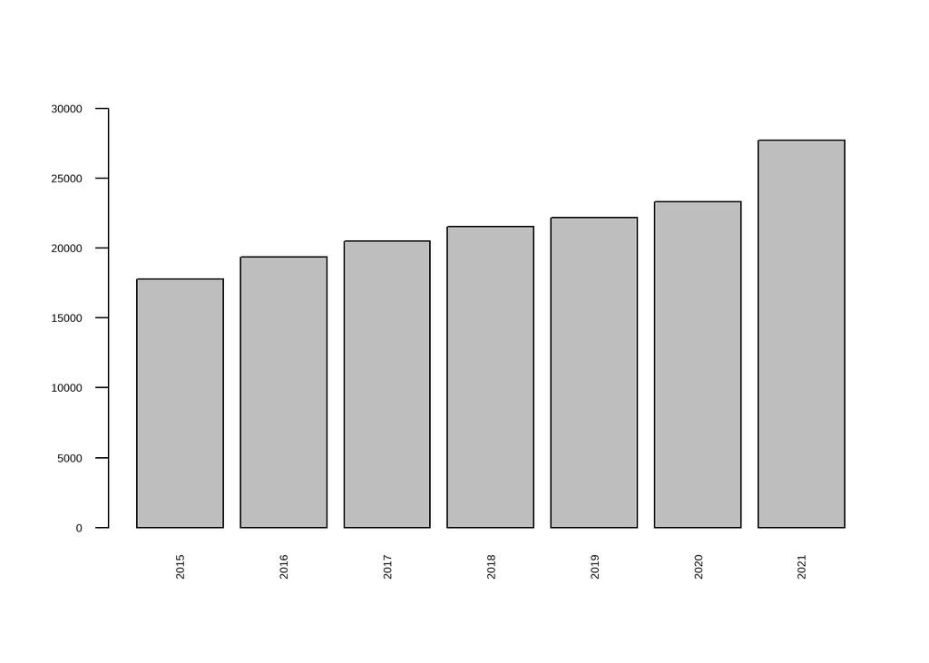

```r
barplot(table(data$year), ylim=c(0,30000), las = 2)
```

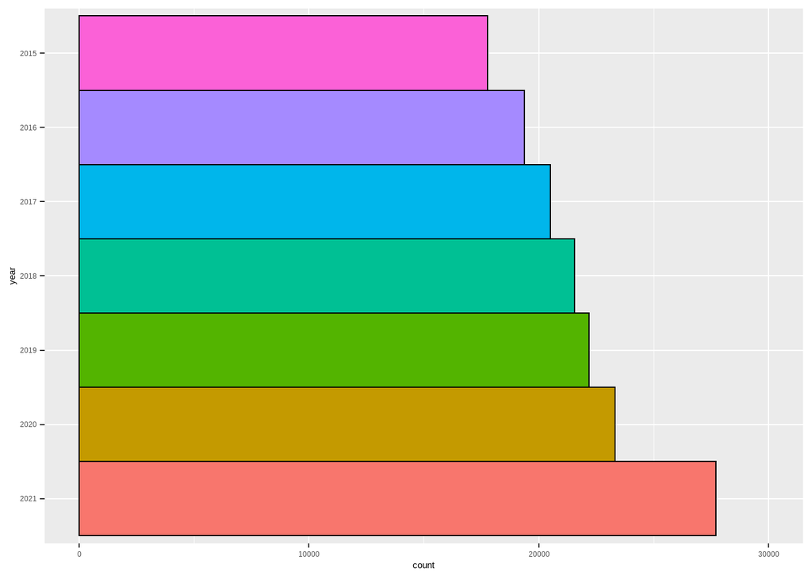

```r
p <- ggplot(data, aes(x = fct_infreq(year), fill = fct_infreq(year))) +
  geom_bar(width = 1, colour = "black", show.legend = FALSE) +
  xlab("year")

p + coord_flip() + scale_y_continuous(limit = c(0, 30000))
```

- exploration of month by plotting

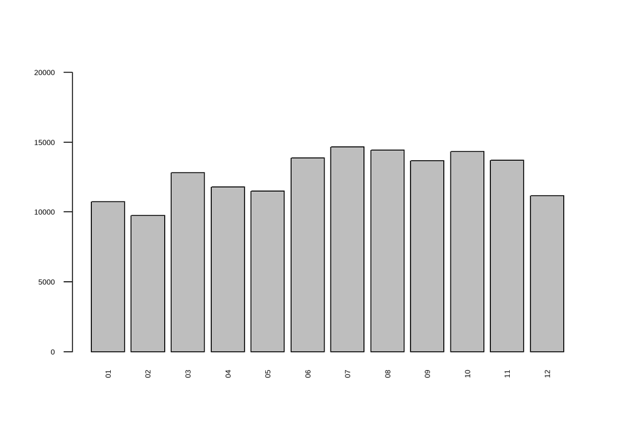

```r
barplot(table(data$month), ylim=c(0,20000), las = 2)
```

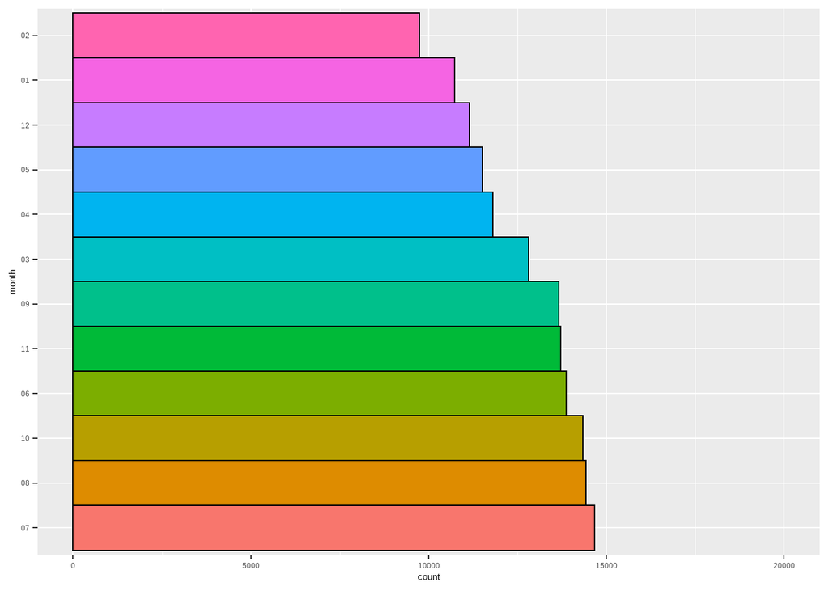

```r
p <- ggplot(data, aes(x = fct_infreq(month), fill = fct_infreq(month))) +
  geom_bar(width = 1, colour = "black", show.legend = FALSE) +
  xlab("month")

p + coord_flip() + scale_y_continuous(limit = c(0, 20000))
```

- uniform distribution type
- the transaction records in every month are about the same, ranges from 9,000 to 15,000
- July has the highest transaction records
- February has the lowest transaction records

### 2. town

```r
head(data$town)
```

```
## [1] "ANG MO KIO" "ANG MO KIO" "ANG MO KIO" "ANG MO KIO" "ANG MO KIO"
## [6] "ANG MO KIO"
```

```r
tail(data$town)
```

```
## [1] "YISHUN" "YISHUN" "YISHUN" "YISHUN" "YISHUN" "YISHUN"
```

```r
str(data$town)
```

```
##  chr [1:152455] "ANG MO KIO" "ANG MO KIO" "ANG MO KIO" "ANG MO KIO" ...
```

- explore the number of distinct values of town
- convert to factor

```r
data %>% distinct(town)
```

```
##               town
## 1       ANG MO KIO
## 2            BEDOK
## 3           BISHAN
## 4      BUKIT BATOK
## 5      BUKIT MERAH
## 6    BUKIT PANJANG
## 7      BUKIT TIMAH
## 8     CENTRAL AREA
## 9    CHOA CHU KANG
## 10        CLEMENTI
## 11         GEYLANG
## 12         HOUGANG
## 13     JURONG EAST
## 14     JURONG WEST
## 15 KALLANG/WHAMPOA
## 16   MARINE PARADE
## 17       PASIR RIS
## 18         PUNGGOL
## 19      QUEENSTOWN
## 20       SEMBAWANG
## 21        SENGKANG
## 22       SERANGOON
## 23        TAMPINES
## 24       TOA PAYOH
## 25       WOODLANDS
## 26          YISHUN
```

```r
data %>% summarise(na = sum(is.na(town)))
```

```
##   na
## 1  0
```

```r
data$town <- as.factor(data$town)

str(data$town)
```

```
##  Factor w/ 26 levels "ANG MO KIO","BEDOK",..: 1 1 1 1 1 1 1 1 1 1 ...
```

```r
sort(summary(data$town))
```

```
##     BUKIT TIMAH   MARINE PARADE    CENTRAL AREA          BISHAN       SERANGOON
##             402             942            1373            2956            3067
##     JURONG EAST        CLEMENTI       SEMBAWANG         GEYLANG      QUEENSTOWN
##            3327            3570            3703            3857            4285
## KALLANG/WHAMPOA       PASIR RIS       TOA PAYOH     BUKIT BATOK     BUKIT MERAH
##            4465            4765            4828            5353            5860
##   BUKIT PANJANG      ANG MO KIO   CHOA CHU KANG         HOUGANG           BEDOK
##            5922            6770            6874            7529            8726
##          YISHUN         PUNGGOL        TAMPINES       WOODLANDS     JURONG WEST
##            9822            9938           10502           10550           10711
##        SENGKANG
##           12358
```

- there’s no missing value
- exploration by plotting

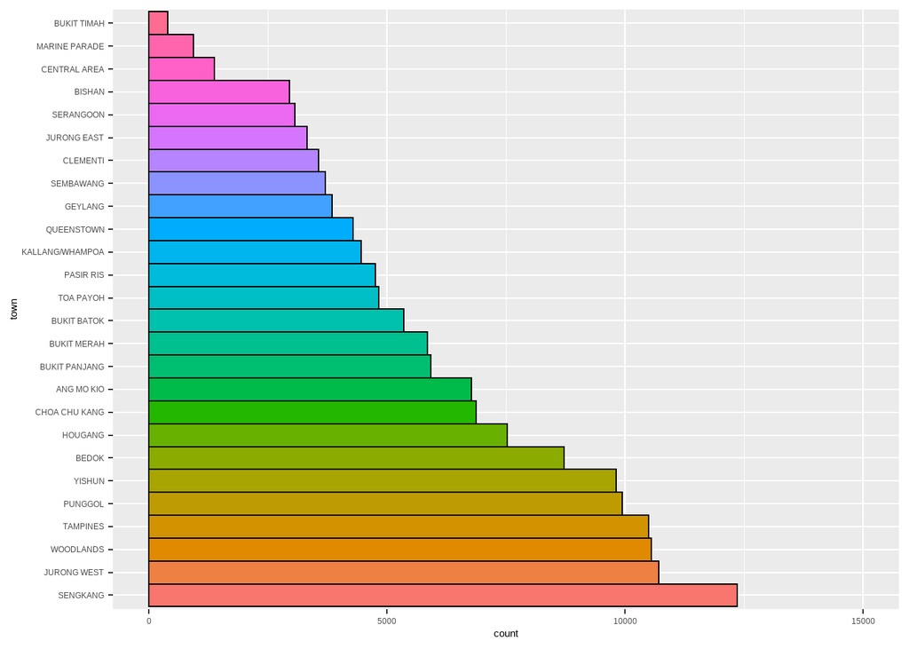

```r
p <- ggplot(data, aes(x = fct_infreq(town), fill = fct_infreq(town))) +
  geom_bar(width = 1, colour = "black", show.legend = FALSE) +
  xlab("town")

p + coord_flip() + scale_y_continuous(limit = c(0, 15000))
```

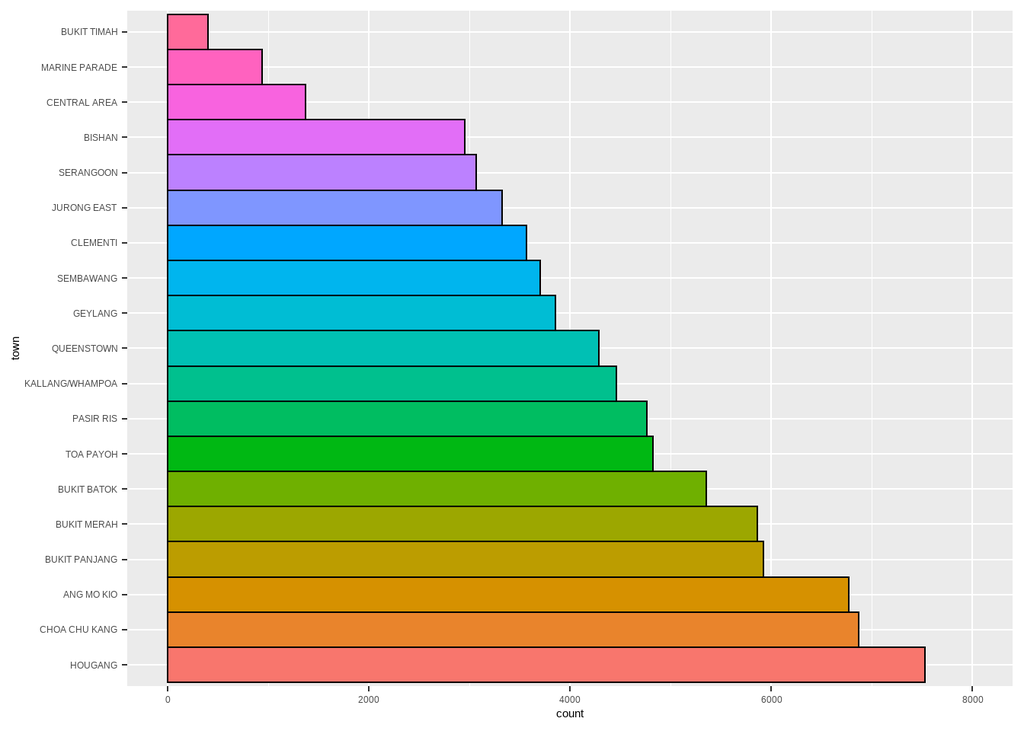

```r
# Zoom in to town with frequency < 10,000
data_filter <- data %>%
  group_by(town) %>%
  filter(n() < 8000)

p <- ggplot(data_filter, aes(x = fct_infreq(town), fill = fct_infreq(town))) +
  geom_bar(width = 1, colour = "black", show.legend = FALSE) +
  xlab("town")

p + coord_flip() + scale_y_continuous(limit = c(0, 8000))
```

- SENGKANG has the highest transaction records, more than 10,000 rows
- BUKIT TIMAH has the lowest transaction records, less than 1,000 rows
- classify towns into region (refer to https://www.mappr.co/counties/regions-of-singapore/)
- classify BUKIT TIMAH as central region (refer to https://en.wikipedia.org/wiki/Bukit_Timah)

```r
data$region <- ifelse (data$town %in% c("BUKIT MERAH","BUKIT TIMAH","GEYLANG","TOA PAYOH",
                                        "BISHAN","KALLANG/WHAMPOA","MARINE PARADE", "CENTRAL AREA", "QUEENSTOWN"), "Central",
                       ifelse (data$town %in% c("TAMPINES","BEDOK","PASIR RIS"), "East",
                               ifelse (data$town %in% c("LIM CHU KANG","SEMBAWANG","WOODLANDS","YISHUN"), "North",
                                       ifelse (data$town %in% c("ANG MO KIO","HOUGANG","PUNGGOL","SENGKANG",
                                                                "SERANGOON"), "North-East",
                                               ifelse (data$town %in% c("BUKIT BATOK","BUKIT PANJANG",
                                                                        "CHOA CHU KANG","CLEMENTI",
                                                                        "JURONG EAST","JURONG WEST"), "West",
                                                       as.character(data$town))))))

head(data)
```

```
##   year month       town flat_type block       street_name storey_range
## 1 2015    01 ANG MO KIO    3 ROOM   174  ANG MO KIO AVE 4     07 TO 09
## 2 2015    01 ANG MO KIO    3 ROOM   541 ANG MO KIO AVE 10     01 TO 03
## 3 2015    01 ANG MO KIO    3 ROOM   163  ANG MO KIO AVE 4     01 TO 03
## 4 2015    01 ANG MO KIO    3 ROOM   446 ANG MO KIO AVE 10     01 TO 03
## 5 2015    01 ANG MO KIO    3 ROOM   557 ANG MO KIO AVE 10     07 TO 09
## 6 2015    01 ANG MO KIO    3 ROOM   603  ANG MO KIO AVE 5     07 TO 09
##   floor_area_sqm     flat_model lease_commence_date remaining_lease
## 1             60       Improved                1986              70
## 2             68 New Generation                1981              65
## 3             69 New Generation                1980              64
## 4             68 New Generation                1979              63
## 5             68 New Generation                1980              64
## 6             67 New Generation                1980              64
##   resale_price int_year     region
## 1       255000     2015 North-East
## 2       275000     2015 North-East
## 3       285000     2015 North-East
## 4       290000     2015 North-East
## 5       290000     2015 North-East
## 6       290000     2015 North-East
```

```r
head(data$region)
```

```
## [1] "North-East" "North-East" "North-East" "North-East" "North-East"
## [6] "North-East"
```

```r
tail(data$region)
```

```
## [1] "North" "North" "North" "North" "North" "North"
```

```r
str(data$region)
```

```
##  chr [1:152455] "North-East" "North-East" "North-East" "North-East" ...
```

```r
data$region <- as.factor(data$region)

str(data$region)
```

```
##  Factor w/ 5 levels "Central","East",..: 4 4 4 4 4 4 4 4 4 4 ...
```

```r
sort(summary(data$region))
```

```
##       East      North    Central       West North-East
##      23993      24075      28968      35757      39662
```

- exploration by plotting

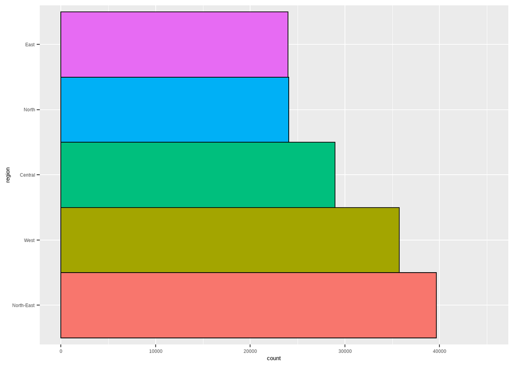

```r
p <- ggplot(data, aes(x = fct_infreq(region), fill = fct_infreq(region))) +
  geom_bar(width = 1, colour = "black", show.legend = FALSE) +
  xlab("region")

p + coord_flip() + scale_y_continuous(limit = c(0, 45000))
```

- North-East has the highest transaction records, nearly 40,000 rows
- East has the lowest transaction records, less than 25,000 rows

### 3. flat_type

```r
head(data$flat_type)
```

```
## [1] "3 ROOM" "3 ROOM" "3 ROOM" "3 ROOM" "3 ROOM" "3 ROOM"
```

```r
tail(data$flat_type)
```

```
## [1] "EXECUTIVE"        "MULTI-GENERATION" "MULTI-GENERATION" "MULTI-GENERATION"
## [5] "MULTI-GENERATION" "MULTI-GENERATION"
```

```r
str(data$flat_type)
```

```
##  chr [1:152455] "3 ROOM" "3 ROOM" "3 ROOM" "3 ROOM" "3 ROOM" "3 ROOM" ...
```

- explore the number of distinct values of flat type

```r
data %>% distinct(flat_type)
```

```
##          flat_type
## 1           3 ROOM
## 2           4 ROOM
## 3           5 ROOM
## 4           2 ROOM
## 5        EXECUTIVE
## 6           1 ROOM
## 7 MULTI-GENERATION
```

```r
data %>% summarise(na = sum(is.na(flat_type)))
```

```
##   na
## 1  0
```

- there’s no missing value
- convert to factor

```r
data$flat_type <- as.factor(data$flat_type)

str(data$flat_type)
```

```
##  Factor w/ 7 levels "1 ROOM","2 ROOM",..: 3 3 3 3 3 3 3 3 3 3 ...
```

```r
sort(summary(data$flat_type))
```

```
##           1 ROOM MULTI-GENERATION           2 ROOM        EXECUTIVE
##               62               65             2051            12046
##           3 ROOM           5 ROOM           4 ROOM
##            36960            38069            63202
```

- exploration by plotting

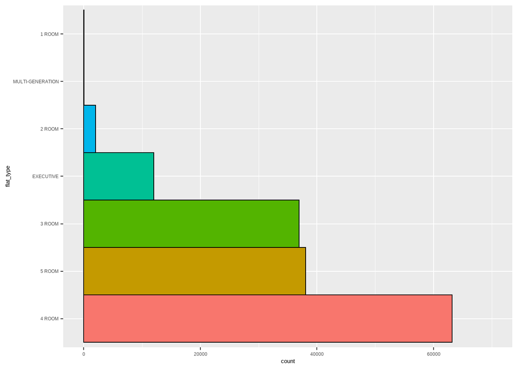

```r
p <- ggplot(data, aes(x = fct_infreq(flat_type), fill = fct_infreq(flat_type))) +
  geom_bar(width = 1, colour = "black", show.legend = FALSE) +
  xlab("flat_type")

p + coord_flip() + scale_y_continuous(limit = c(0, 70000))
```

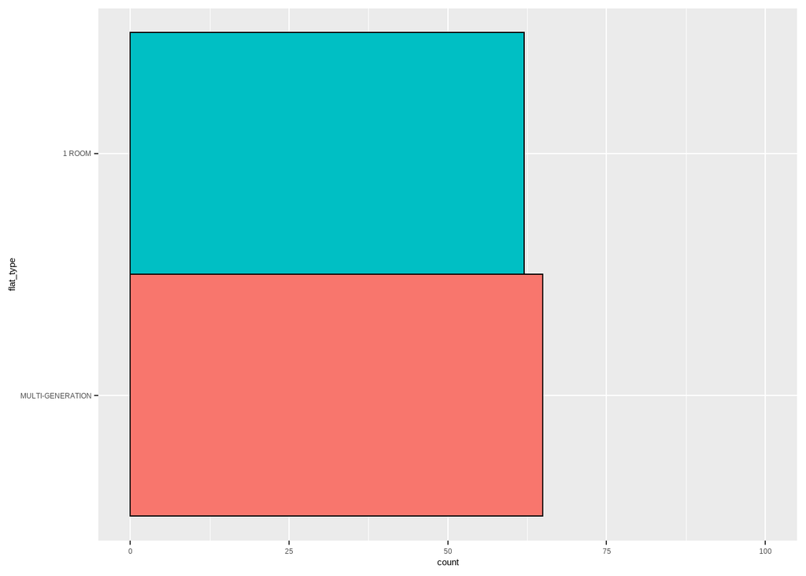

```r
# Zoom in
data_filter <- data %>%
  group_by(flat_type) %>%
  filter(n() < 100)

p <- ggplot(data_filter, aes(x = fct_infreq(flat_type), fill = fct_infreq(flat_type))) +
  geom_bar(width = 1, colour = "black", show.legend = FALSE) +
  xlab("flat_type")

p + coord_flip() + scale_y_continuous(limit = c(0, 100))
```

- 4 ROOM type HDB has the highest transaction records, more than 60,000 rows
- 1 ROOM type HDB has the lowest transaction records, less than 100 rows
- both MULTI-GENERATION and 1 ROOM type HDB have less than 100 transaction records, it is logical as not much HDB in these two types
- reference: https://www.hdb.gov.sg/residential/buying-a-flat/resale/getting-started/types-of-flats
- MULTI-GENERATION:
- Eligible multi-generation families living under one roof in a 3Gen flat can delight in closer family ties. With 2 bedrooms with attached bathrooms, and 2 other bedrooms, it easily supports the needs of larger households.

### 4. block

```r
head(data$block)
```

```
## [1] "174" "541" "163" "446" "557" "603"
```

```r
tail(data$block)
```

```
## [1] "824" "666" "666" "633" "632" "633"
```

```r
str(data$block)
```

```
##  chr [1:152455] "174" "541" "163" "446" "557" "603" "709" "333" "109" "564" ...
```

- explore the number of distinct values of block
- convert to factor

```r
data %>%
  distinct(block) %>%
  head()
```

```
##   block
## 1   174
## 2   541
## 3   163
## 4   446
## 5   557
## 6   603
```

```r
data %>%
  distinct(block) %>%
  tail()
```

```
##      block
## 2560  512B
## 2561  512A
## 2562  509C
## 2563  511A
## 2564  511B
## 2565  512C
```

```r
data %>% summarise(na = sum(is.na(block)))
```

```
##   na
## 1  0
```

```r
data$block <- as.factor(data$block)

str(data$block)
```

```
##  Factor w/ 2565 levels "1","10","100",..: 246 1538 200 1207 1568 1649 2019 903 39 1576 ...
```

```r
sort(summary(data$block))
```

```
##     535      27     407      26     205     132     230     140     418     202
##     209     210     211     212     213     214     214     215     215     218
##     134     154     408     231      35      53     229      44      16     204
##     219     219     220     221     221     222     223     224     225     226
##      43     148     208     411     417     421     138     232     420      51
##     226     227     227     227     227     230     231     231     231     232
##     131     211     416     135     406      57      30     145     118     146
##     233     235     235     237     238     239     241     242     245     247
##     141     142     425      15      10     123      55      54     104     129
##     249     249     249     251     252     253     259     260     263     263
##      19      32     126     210     119     128      18     120     117     106
##     264     269     273     274     275     284     288     297     298     308
##      50     124     125     122      28      34     116      23      17      21
##     308     313     315     316     316     320     321     323     326     326
##     103     105     130      11       5     121      13      12       6     102
##     336     341     346     352     354     355     357     358     361     365
##      20     111     112      22       4     115     107       7     109       3
##     372     376     380     380     389     390     392     394     398     398
##     113     110       9     114     108     101       1       8       2 (Other)
##     401     403     408     418     421     440     462     498     549  123467
```

- there’s no missing value
- exploration by plotting
- select blocks of top 10 highest transaction records and top 10 lowest transaction records

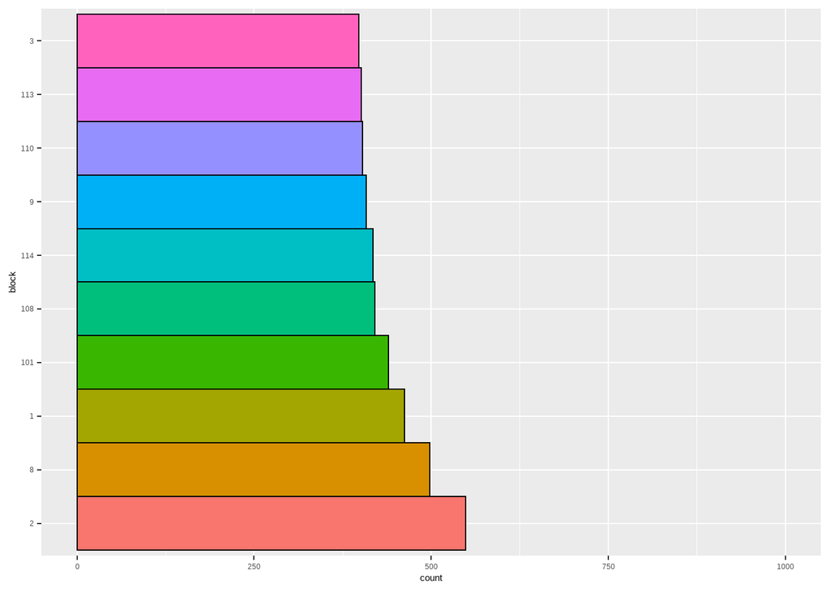

```r
groupby_block <- data  %>%
     group_by(block) %>%
     summarise(n = n()) %>%
     arrange(n, decreasing = TRUE)

btm10 <- head(groupby_block,10)
top10 <- tail(groupby_block,10)

# TOP 10 block with highest transactions
data_filter <- data %>%
  filter(block %in% top10$block)

p <- ggplot(data_filter, aes(x = fct_infreq(block), fill = fct_infreq(block))) +
  geom_bar(width = 1, colour = "black", show.legend = FALSE) +
  xlab("block")

p + coord_flip() + scale_y_continuous(limit = c(0, 1000))
```

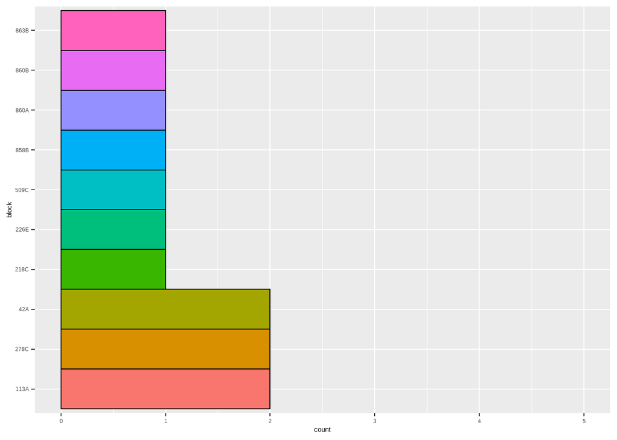

```r
# BOTTOM 10 block with lowest transactions
data_filter <- data %>%
  filter(block %in% btm10$block)

p <- ggplot(data_filter, aes(x = fct_infreq(block), fill = fct_infreq(block))) +
  geom_bar(width = 1, colour = "black", show.legend = FALSE) +
  xlab("block")

p + coord_flip() + scale_y_continuous(limit = c(0, 5))
```

- remove the alphabet in block number to reduce the number of unique value

```r
data$block <- gsub("[^0-9.-]", "", data$block)
head(data$block)
```

```
## [1] "174" "541" "163" "446" "557" "603"
```

```r
tail(data$block)
```

```
## [1] "824" "666" "666" "633" "632" "633"
```

- exploration by plotting
- select blocks of top 10 highest transaction records and top 10 lowest transaction records

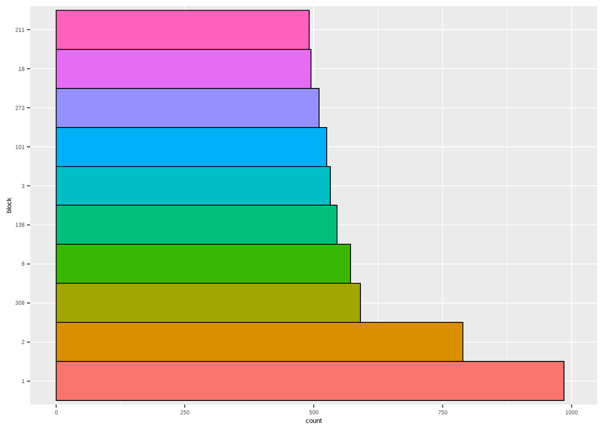

```r
groupby_block <- data  %>%
     group_by(block) %>%
     summarise(n = n()) %>%
     arrange(n, decreasing = TRUE)

btm10 <- head(groupby_block,10)
top10 <- tail(groupby_block,10)

# TOP 10 block with highest transactions
data_filter <- data %>%
  filter(block %in% top10$block)

p <- ggplot(data_filter, aes(x = fct_infreq(block), fill = fct_infreq(block))) +
  geom_bar(width = 1, colour = "black", show.legend = FALSE) +
  xlab("block")

p + coord_flip() + scale_y_continuous(limit = c(0, 1000))
```

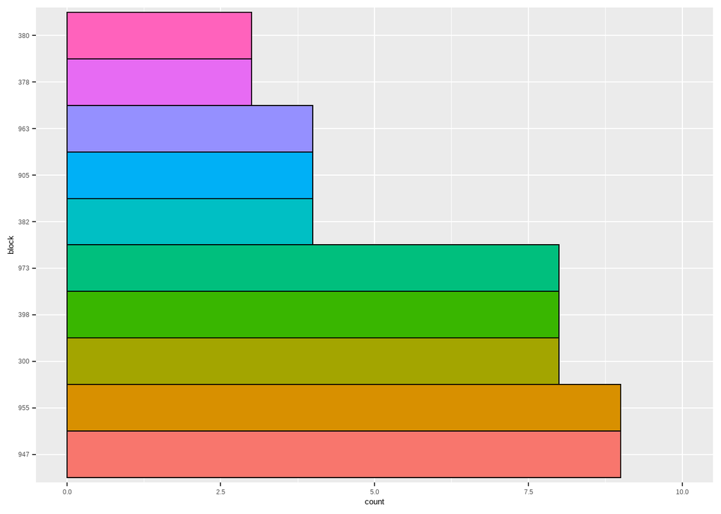

```r
# BOTTOM 10 block with lowest transactions
data_filter <- data %>%
  filter(block %in% btm10$block)

p <- ggplot(data_filter, aes(x = fct_infreq(block), fill = fct_infreq(block))) +
  geom_bar(width = 1, colour = "black", show.legend = FALSE) +
  xlab("block")

p + coord_flip() + scale_y_continuous(limit = c(0, 10))
```

### 5. street_name

```r
head(data$street_name)
```

```
## [1] "ANG MO KIO AVE 4"  "ANG MO KIO AVE 10" "ANG MO KIO AVE 4"
## [4] "ANG MO KIO AVE 10" "ANG MO KIO AVE 10" "ANG MO KIO AVE 5"
```

```r
tail(data$street_name)
```

```
## [1] "YISHUN ST 81" "YISHUN AVE 4" "YISHUN AVE 4" "YISHUN ST 61" "YISHUN ST 61"
## [6] "YISHUN ST 61"
```

```r
str(data$street_name)
```

```
##  chr [1:152455] "ANG MO KIO AVE 4" "ANG MO KIO AVE 10" "ANG MO KIO AVE 4" ...
```

- explore the number of distinct values of street_name
- convert to factor

```r
data %>%
  distinct(street_name) %>%
  head()
```

```
##         street_name
## 1  ANG MO KIO AVE 4
## 2 ANG MO KIO AVE 10
## 3  ANG MO KIO AVE 5
## 4  ANG MO KIO AVE 8
## 5  ANG MO KIO AVE 1
## 6  ANG MO KIO AVE 3
```

```r
data %>%
  distinct(street_name) %>%
  tail()
```

```
##        street_name
## 551 TAMPINES ST 86
## 552 KEAT HONG LINK
## 553 ALJUNIED AVE 2
## 554    SUMANG LANE
## 555  CANBERRA CRES
## 556    CANBERRA ST
```

```r
data %>% summarise(na = sum(is.na(street_name)))
```

```
##   na
## 1  0
```

```r
data$street_name <- as.factor(data$street_name)

str(data$street_name)
```

```
##  Factor w/ 556 levels "ADMIRALTY DR",..: 17 14 17 14 14 18 20 13 17 16 ...
```

```r
sort(summary(data$street_name))
```

```
##       HOUGANG AVE 5 CHOA CHU KANG AVE 3      TAMPINES ST 83  TELOK BLANGAH CRES
##                 445                 453                 456                 462
##         JLN MEMBINA          EUNOS CRES            FAJAR RD     LOR 2 TOA PAYOH
##                 463                 464                 466                 468
##     WOODLANDS AVE 1         CANBERRA RD   JURONG WEST ST 41         PUNGGOL WAY
##                 470                 472                 473                 483
##     TAMPINES CTRL 7     WOODLANDS DR 16     PASIR RIS ST 11        YISHUN AVE 6
##                 484                 486                 490                 493
##      HOUGANG AVE 10   JURONG WEST ST 91     WOODLANDS DR 75   SENGKANG WEST WAY
##                 496                 500                 504                 506
##        YISHUN ST 81       HOUGANG AVE 1      TAMPINES ST 71        YISHUN ST 21
##                 513                 514                 519                 519
##       CANTONMENT RD      STRATHMORE AVE        YISHUN ST 61      TAMPINES ST 41
##                 524                 526                 530                 531
##           UBI AVE 1      PASIR RIS DR 6 SERANGOON NTH AVE 1      ADMIRALTY LINK
##                 533                 534                 535                 538
##   JURONG WEST ST 52 SERANGOON NTH AVE 4        YISHUN ST 11     WOODLANDS ST 13
##                 551                 551                 552                 556
##      TAMPINES ST 22     PASIR RIS ST 21    WOODLANDS CIRCLE      TECK WHYE LANE
##                 563                 566                 567                 569
##        BISHAN ST 13      COMPASSVALE ST  BT PANJANG RING RD       ANCHORVALE RD
##                 573                 575                 580                 587
##         BOON LAY DR        BISHAN ST 12      WOODLANDS CRES     WOODLANDS DR 14
##                 587                 589                 593                 595
##    COMPASSVALE LINK CHOA CHU KANG AVE 5     PASIR RIS ST 71    COMPASSVALE LANE
##                 602                 603                 606                 625
##       TEBAN GDNS RD   JURONG WEST ST 81          SIMEI ST 1        SEMBAWANG DR
##                 630                 632                 643                 653
## CHOA CHU KANG AVE 4 BT BATOK WEST AVE 6        ADMIRALTY DR     WOODLANDS DR 50
##                 666                 669                 679                 679
##         JELAPANG RD     LOR 1 TOA PAYOH   JURONG WEST ST 42    ANG MO KIO AVE 1
##                 689                 695                 698                 702
##   WOODLANDS RING RD      CLEMENTI AVE 4     PASIR RIS ST 51   JURONG EAST ST 21
##                 706                 709                 727                 729
##        MARSILING DR    ANG MO KIO AVE 5          CIRCUIT RD     ANCHORVALE LINK
##                 730                 769                 776                 778
##   JURONG WEST ST 61       FERNVALE LINK        RIVERVALE DR     EDGEDALE PLAINS
##                 790                 801                 828                 831
##    ANG MO KIO AVE 4      TAMPINES ST 21   JURONG WEST ST 64      BEDOK NTH ST 3
##                 838                 853                 868                 923
##        PUNGGOL WALK   JURONG WEST ST 65        BEDOK NTH RD      RIVERVALE CRES
##                 974                 986                1001                1049
##            SENJA RD  CHOA CHU KANG CRES       YISHUN AVE 11          PUNGGOL PL
##                1103                1107                1118                1125
##       HOUGANG AVE 8            SEGAR RD    EDGEFIELD PLAINS        PUNGGOL CTRL
##                1133                1187                1193                1368
##         FERNVALE RD    ANG MO KIO AVE 3       PUNGGOL FIELD          PUNGGOL DR
##                1403                1521                1550                1567
##   ANG MO KIO AVE 10  BEDOK RESERVOIR RD      YISHUN RING RD             (Other)
##                1622                1776                2252               79289
```

- there’s no missing value
- exploration by plotting
- select street name of top 10 highest transaction records and top 10 lowest transaction records

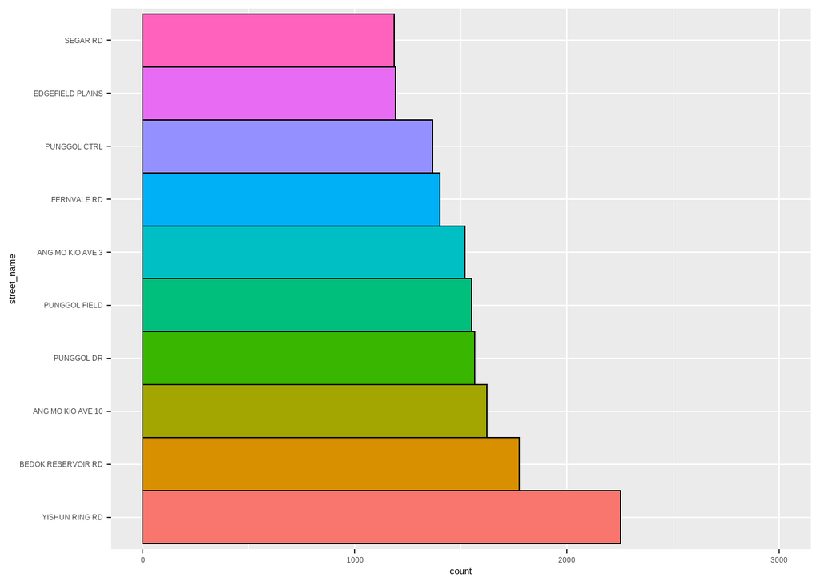

```r
groupby_street <- data  %>%
     group_by(street_name) %>%
     summarise(n = n()) %>%
     arrange(n, decreasing = TRUE)

btm10 <- head(groupby_street,10)
top10 <- tail(groupby_street,10)

# TOP 10 street_name with highest transactions
data_filter <- data %>%
  filter(street_name %in% top10$street_name)

p <- ggplot(data_filter, aes(x = fct_infreq(street_name), fill = fct_infreq(street_name))) +
  geom_bar(width = 1, colour = "black", show.legend = FALSE) +
  xlab("street_name")

p + coord_flip() + scale_y_continuous(limit = c(0, 3000))
```

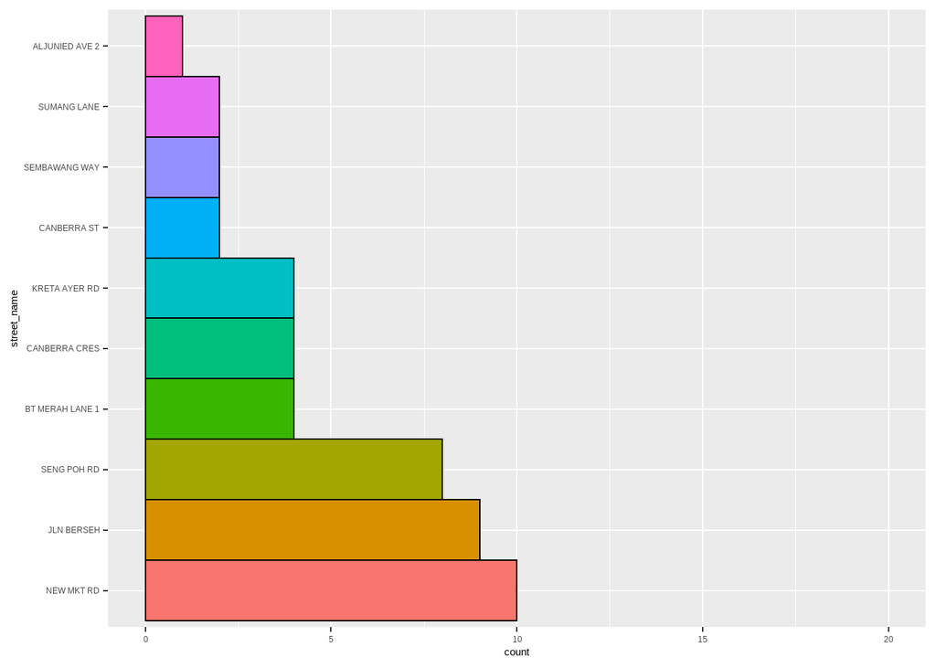

```r
# BOTTOM 10 street_name with lowest transactions
data_filter <- data %>%
  filter(street_name %in% btm10$street_name)

p <- ggplot(data_filter, aes(x = fct_infreq(street_name), fill = fct_infreq(street_name))) +
  geom_bar(width = 1, colour = "black", show.legend = FALSE) +
  xlab("street_name")

p + coord_flip() + scale_y_continuous(limit = c(0, 20))
```

### 6. storey_range

```r
head(data$storey_range)
```

```
## [1] "07 TO 09" "01 TO 03" "01 TO 03" "01 TO 03" "07 TO 09" "07 TO 09"
```

```r
tail(data$storey_range)
```

```
## [1] "04 TO 06" "10 TO 12" "07 TO 09" "10 TO 12" "01 TO 03" "07 TO 09"
```

```r
str(data$storey_range)
```

```
##  chr [1:152455] "07 TO 09" "01 TO 03" "01 TO 03" "01 TO 03" "07 TO 09" ...
```

- explore the number of distinct values of storey_range

```r
unique(sort(data$storey_range))
```

```
##  [1] "01 TO 03" "04 TO 06" "07 TO 09" "10 TO 12" "13 TO 15" "16 TO 18"
##  [7] "19 TO 21" "22 TO 24" "25 TO 27" "28 TO 30" "31 TO 33" "34 TO 36"
## [13] "37 TO 39" "40 TO 42" "43 TO 45" "46 TO 48" "49 TO 51"
```

```r
data %>% summarise(na = sum(is.na(storey_range)))
```

```
##   na
## 1  0
```

- there’s no missing value
- convert storey_range to factor

```r
data$storey_range <- as.factor(data$storey_range)
sort(summary(data$storey_range))
```

```
## 49 TO 51 46 TO 48 43 TO 45 40 TO 42 37 TO 39 34 TO 36 31 TO 33 28 TO 30
##       12       36       39      157      312      325      347      692
## 25 TO 27 22 TO 24 19 TO 21 16 TO 18 13 TO 15 01 TO 03 10 TO 12 07 TO 09
##     1096     1999     2708     6440    14199    27587    28529    32320
## 04 TO 06
##    35657
```

- exploration by plotting

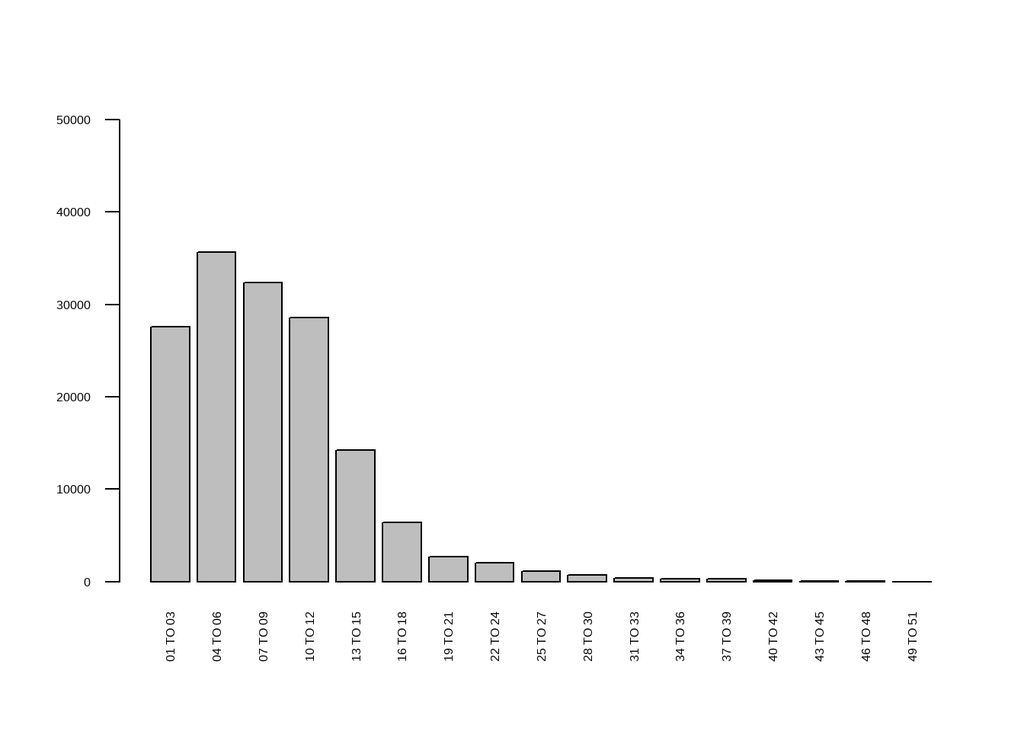

```r
barplot(table(data$storey_range), ylim=c(0,50000), las = 2)
```

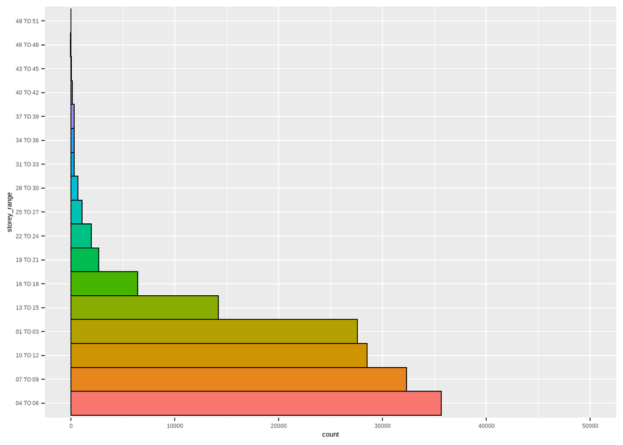

```r
p <- ggplot(data, aes(x = fct_infreq(storey_range), fill = fct_infreq(storey_range))) +
  geom_bar(width = 1, colour = "black", show.legend = FALSE) +
  xlab("storey_range")

p + coord_flip() + scale_y_continuous(limit = c(0, 50000))
```

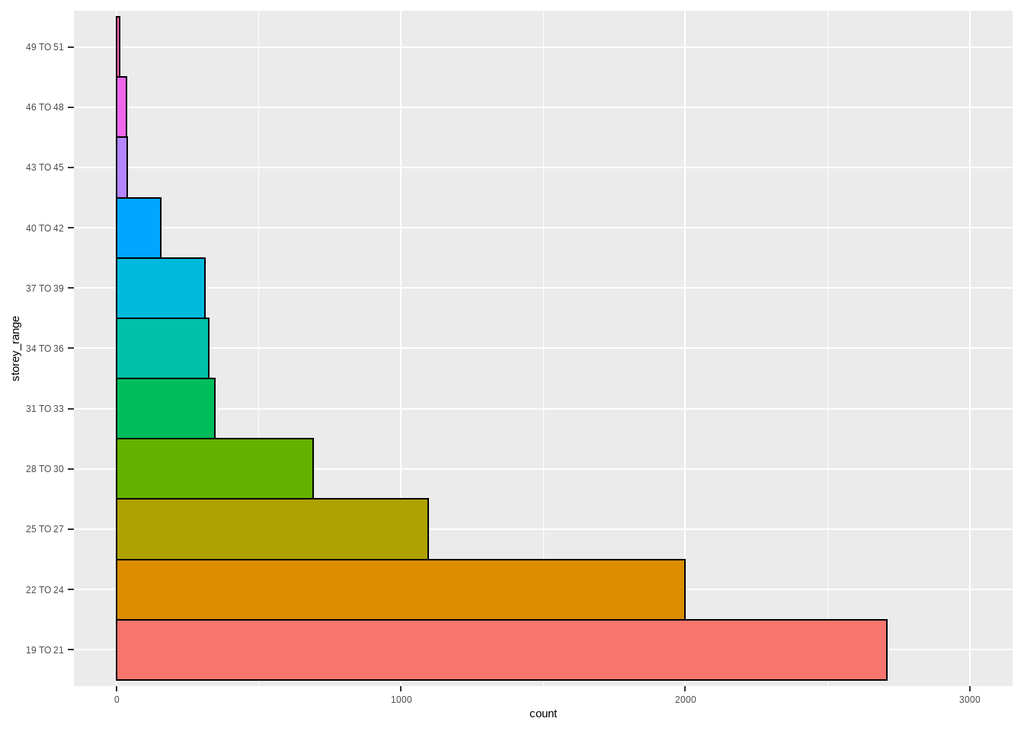

```r
# Zoom in
data_filter <- data %>%
  group_by(storey_range) %>%
  filter(n() < 3000)

p <- ggplot(data_filter, aes(x = fct_infreq(storey_range), fill = fct_infreq(storey_range))) +
  geom_bar(width = 1, colour = "black", show.legend = FALSE) +
  xlab("storey_range")

p + coord_flip() + scale_y_continuous(limit = c(0, 3000))
```

- Storey range of 04 TO 06 has the highest transaction records, more than 35,000 rows
- Storey range of 49 TO 51 has the lowest transaction records, less than 500 rows
- Most of the HDB are <= 12 floors

### 7. floor_area_sqm

```r
head(data$floor_area_sqm)
```

```
## [1] 60 68 69 68 68 67
```

```r
tail(data$floor_area_sqm)
```

```
## [1] 146 179 164 171 164 171
```

```r
str(data$floor_area_sqm)
```

```
##  num [1:152455] 60 68 69 68 68 67 68 68 67 68 ...
```

```r
data %>% summarise(na = sum(is.nan(floor_area_sqm)))
```

```
##   na
## 1  0
```

```r
summary(data$floor_area_sqm)
```

```
##    Min. 1st Qu.  Median    Mean 3rd Qu.    Max.
##   31.00   82.00   95.00   97.65  113.00  280.00
```

- there’s no missing value
- exploration by plotting

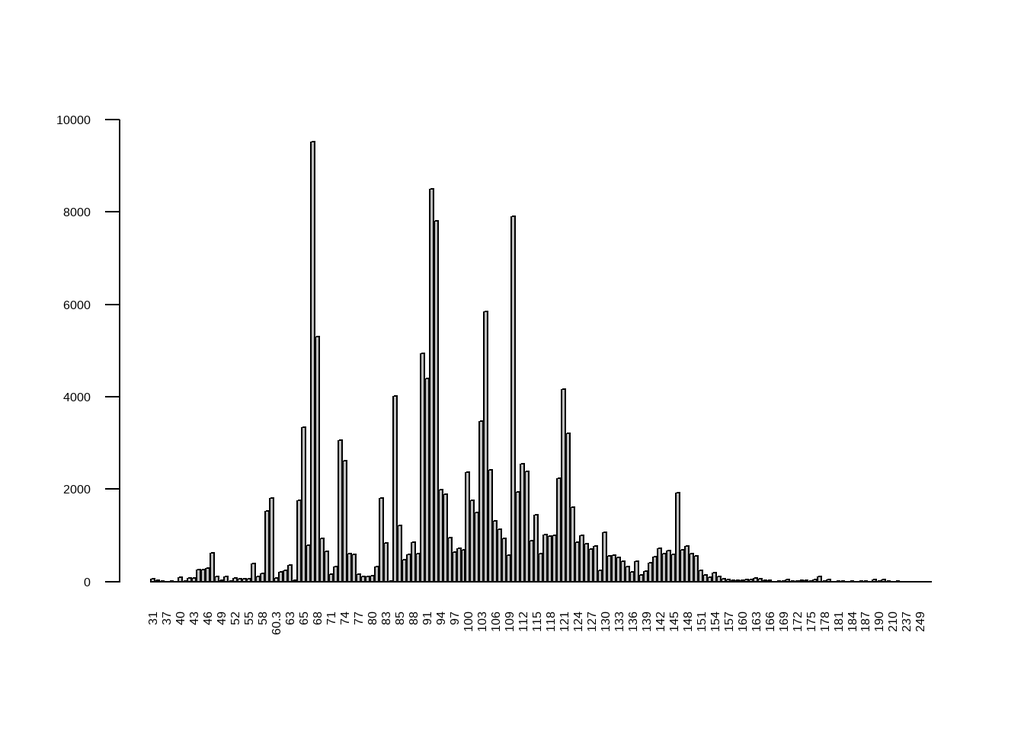

```r
barplot(table(data$floor_area_sqm), ylim=c(0,10000), las = 2)
```

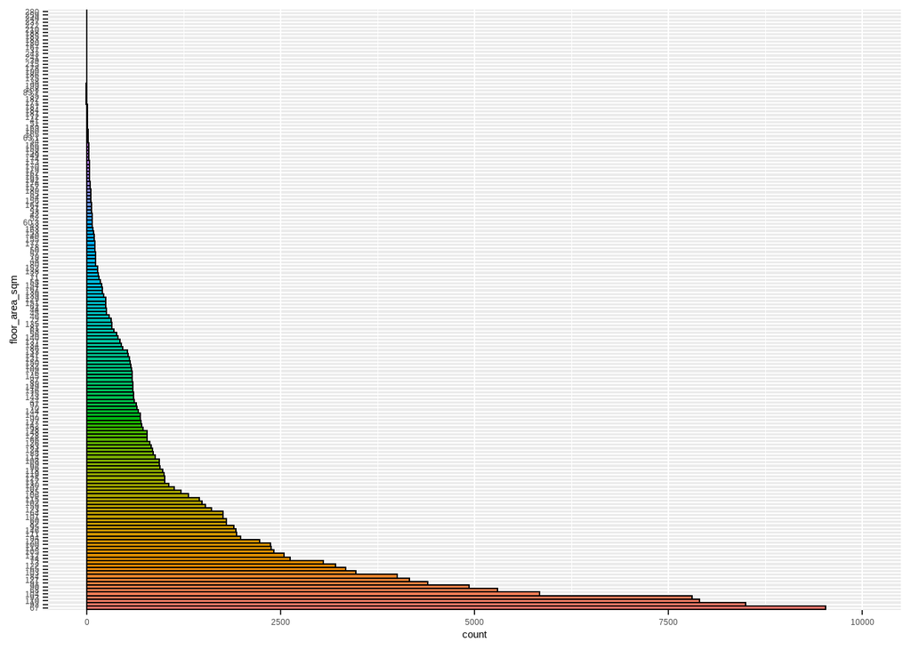

```r
data_plot <- data

data_plot$floor_area_sqm <- as.factor(data_plot$floor_area_sqm)
p <- ggplot(data_plot, aes(x = fct_infreq(floor_area_sqm), fill = fct_infreq(floor_area_sqm))) +
  geom_bar(width = 1, colour = "black", show.legend = FALSE) +
  xlab("floor_area_sqm")

p + coord_flip() + scale_y_continuous(limit = c(0, 10000))
```

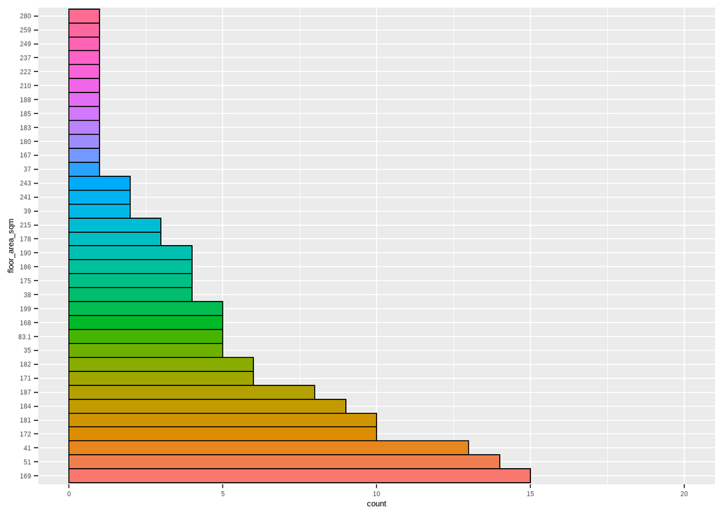

```r
# Zoom in
data_filter <- data_plot %>%
  group_by(floor_area_sqm) %>%
  filter(n() < 20)

p <- ggplot(data_filter, aes(x = fct_infreq(floor_area_sqm), fill = fct_infreq(floor_area_sqm))) +
  geom_bar(width = 1, colour = "black", show.legend = FALSE) +
  xlab("floor_area_sqm")

p + coord_flip() + scale_y_continuous(limit = c(0, 20))
```

- binning

```r
summary(data$floor_area_sqm)
```

```
##    Min. 1st Qu.  Median    Mean 3rd Qu.    Max.
##   31.00   82.00   95.00   97.65  113.00  280.00
```

```r
max(data$floor_area_sqm) -  min(data$floor_area_sqm)
```

```
## [1] 249
```

```r
lower_boundary <- c(seq(30, 270, by=20))
upper_boundary <- c(seq(50, 300, by=20))
lower_boundary
```

```
##  [1]  30  50  70  90 110 130 150 170 190 210 230 250 270
```

```r
upper_boundary
```

```
##  [1]  50  70  90 110 130 150 170 190 210 230 250 270 290
```

```r
bin_label <- c(paste(paste(lower_boundary, "-"),upper_boundary))
bin_label
```

```
##  [1] "30 - 50"   "50 - 70"   "70 - 90"   "90 - 110"  "110 - 130" "130 - 150"
##  [7] "150 - 170" "170 - 190" "190 - 210" "210 - 230" "230 - 250" "250 - 270"
## [13] "270 - 290"
```

```r
data$floor_area_sqm_bins <- cut(data$floor_area_sqm, breaks=c(seq(30, 300, by=20)), labels=bin_label)

data %>% select(floor_area_sqm, floor_area_sqm_bins) %>% head()
```

```
##   floor_area_sqm floor_area_sqm_bins
## 1             60             50 - 70
## 2             68             50 - 70
## 3             69             50 - 70
## 4             68             50 - 70
## 5             68             50 - 70
## 6             67             50 - 70
```

```r
str(data$floor_area_sqm_bins)
```

```
##  Factor w/ 13 levels "30 - 50","50 - 70",..: 2 2 2 2 2 2 2 2 2 2 ...
```

```r
summary(data$floor_area_sqm_bins)
```

```
##   30 - 50   50 - 70   70 - 90  90 - 110 110 - 130 130 - 150 150 - 170 170 - 190
##      2031     27467     23493     56799     29467     11494      1276       369
## 190 - 210 210 - 230 230 - 250 250 - 270 270 - 290
##        47         4         6         1         1
```

```r
data %>% filter(is.na(floor_area_sqm_bins)) %>% select(floor_area_sqm, floor_area_sqm_bins) %>% head()
```

```
## [1] floor_area_sqm      floor_area_sqm_bins
## <0 rows> (or 0-length row.names)
```

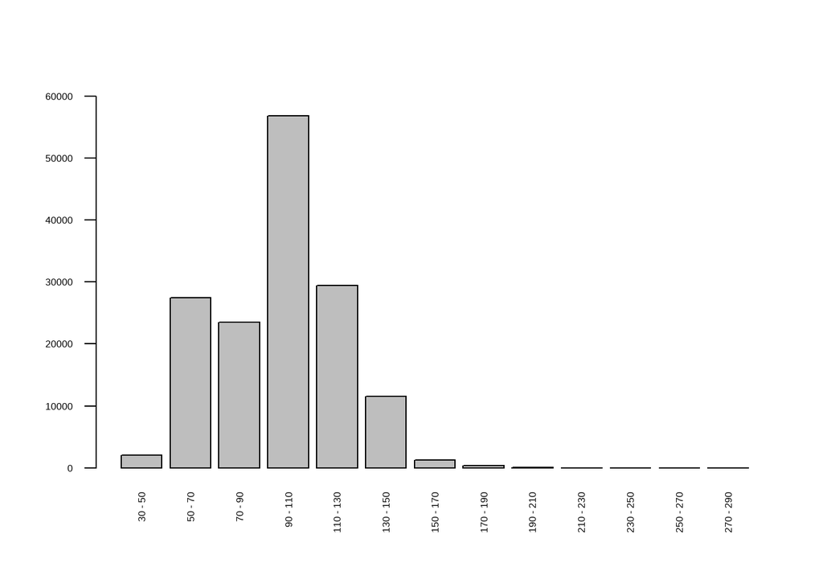

```r
barplot(table(data$floor_area_sqm_bins), ylim=c(0,60000), las = 2)
```

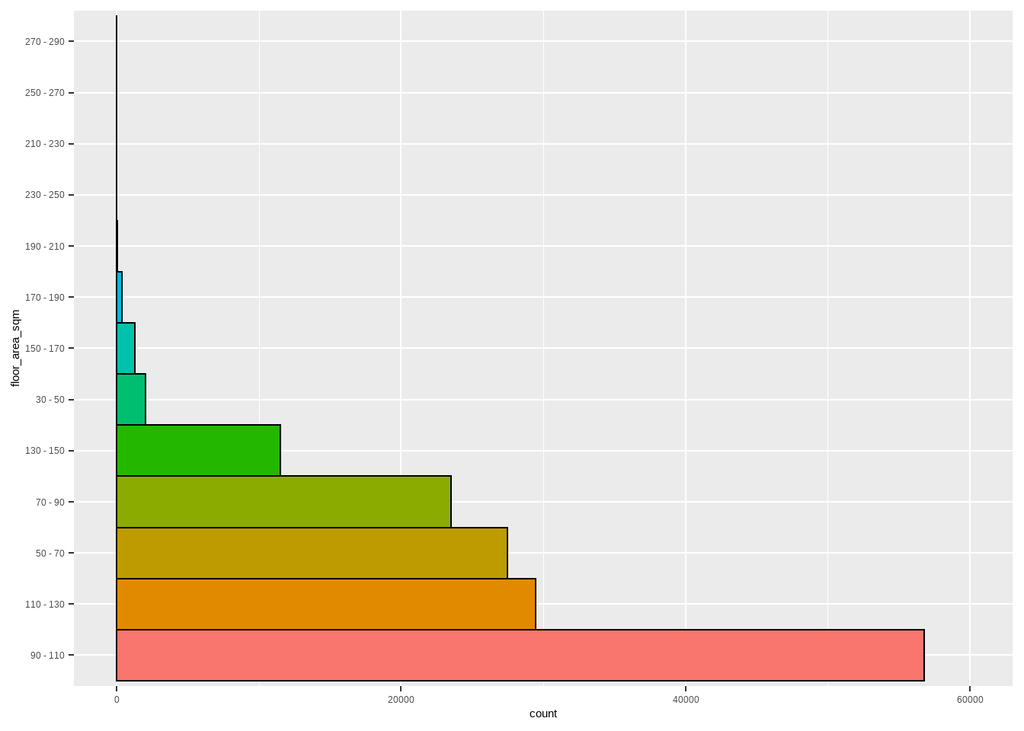

```r
p <- ggplot(data, aes(x = fct_infreq(floor_area_sqm_bins), fill = fct_infreq(floor_area_sqm_bins))) +
  geom_bar(width = 1, colour = "black", show.legend = FALSE) +
  xlab("floor_area_sqm")

p + coord_flip() + scale_y_continuous(limit = c(0, 60000))
```

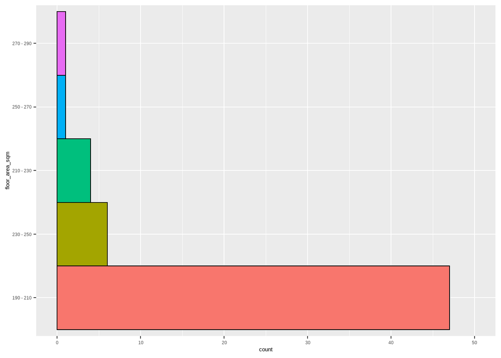

```r
# Zoom in to
data_filter <- data %>%
  group_by(floor_area_sqm_bins) %>%
  filter(n() < 50)

p <- ggplot(data_filter, aes(x = fct_infreq(floor_area_sqm_bins), fill = fct_infreq(floor_area_sqm_bins))) +
  geom_bar(width = 1, colour = "black", show.legend = FALSE) +
  xlab("floor_area_sqm")

p + coord_flip() + scale_y_continuous(limit = c(0, 50))
```

- Floor area (sqm) from 90-110 has the highest transaction records, more than 50,000 rows
- Floor area (sqm) from 250-290 has the lowest transaction records, less than 5 rows
- Most of the HDB has floor area ranges from 50-150 sqm
- Create new column - price per sqm

```r
data$price_per_sqm <- round(data$resale_price / data$floor_area_sqm, 2)
head(data)
```

```
##   year month       town flat_type block       street_name storey_range
## 1 2015    01 ANG MO KIO    3 ROOM   174  ANG MO KIO AVE 4     07 TO 09
## 2 2015    01 ANG MO KIO    3 ROOM   541 ANG MO KIO AVE 10     01 TO 03
## 3 2015    01 ANG MO KIO    3 ROOM   163  ANG MO KIO AVE 4     01 TO 03
## 4 2015    01 ANG MO KIO    3 ROOM   446 ANG MO KIO AVE 10     01 TO 03
## 5 2015    01 ANG MO KIO    3 ROOM   557 ANG MO KIO AVE 10     07 TO 09
## 6 2015    01 ANG MO KIO    3 ROOM   603  ANG MO KIO AVE 5     07 TO 09
##   floor_area_sqm     flat_model lease_commence_date remaining_lease
## 1             60       Improved                1986              70
## 2             68 New Generation                1981              65
## 3             69 New Generation                1980              64
## 4             68 New Generation                1979              63
## 5             68 New Generation                1980              64
## 6             67 New Generation                1980              64
##   resale_price int_year     region floor_area_sqm_bins price_per_sqm
## 1       255000     2015 North-East             50 - 70       4250.00
## 2       275000     2015 North-East             50 - 70       4044.12
## 3       285000     2015 North-East             50 - 70       4130.43
## 4       290000     2015 North-East             50 - 70       4264.71
## 5       290000     2015 North-East             50 - 70       4264.71
## 6       290000     2015 North-East             50 - 70       4328.36
```

```r
tail(data)
```

```
##        year month   town        flat_type block  street_name storey_range
## 152450 2021    12 YISHUN        EXECUTIVE   824 YISHUN ST 81     04 TO 06
## 152451 2021    01 YISHUN MULTI-GENERATION   666 YISHUN AVE 4     10 TO 12
## 152452 2021    11 YISHUN MULTI-GENERATION   666 YISHUN AVE 4     07 TO 09
## 152453 2021    03 YISHUN MULTI-GENERATION   633 YISHUN ST 61     10 TO 12
## 152454 2021    10 YISHUN MULTI-GENERATION   632 YISHUN ST 61     01 TO 03
## 152455 2021    12 YISHUN MULTI-GENERATION   633 YISHUN ST 61     07 TO 09
##        floor_area_sqm       flat_model lease_commence_date    remaining_lease
## 152450            146       Maisonette                1987           65 years
## 152451            179 Multi Generation                1987           66 years
## 152452            164 Multi Generation                1987  65 years 01 month
## 152453            171 Multi Generation                1987 65 years 10 months
## 152454            164 Multi Generation                1987  65 years 01 month
## 152455            171 Multi Generation                1987  65 years 01 month
##        resale_price int_year region floor_area_sqm_bins price_per_sqm
## 152450       755000     2021  North           130 - 150       5171.23
## 152451       860000     2021  North           170 - 190       4804.47
## 152452       838000     2021  North           150 - 170       5109.76
## 152453       860000     2021  North           170 - 190       5029.24
## 152454       760000     2021  North           150 - 170       4634.15
## 152455       865000     2021  North           170 - 190       5058.48
```

```r
str(data$price_per_sqm)
```

```
##  num [1:152455] 4250 4044 4130 4265 4265 ...
```

- exploration by plotting

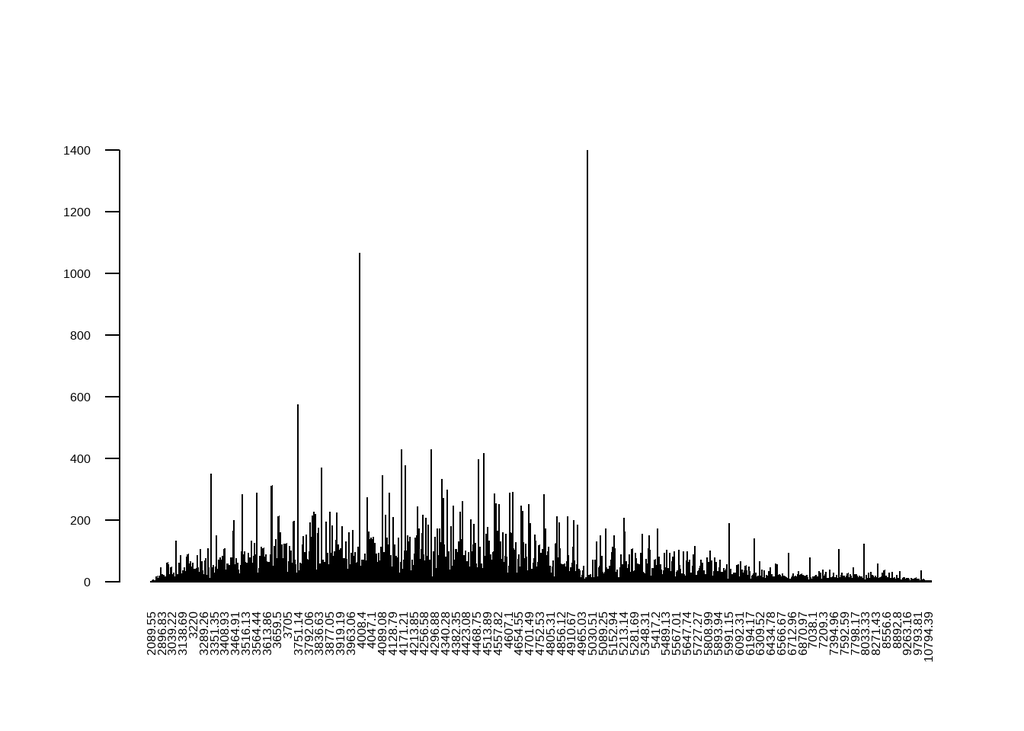

```r
barplot(table(data$price_per_sqm), ylim=c(0,1500), las = 2)
```

### 8. flat_model

```r
head(data$flat_model)
```

```
## [1] "Improved"       "New Generation" "New Generation" "New Generation"
## [5] "New Generation" "New Generation"
```

```r
tail(data$flat_model)
```

```
## [1] "Maisonette"       "Multi Generation" "Multi Generation" "Multi Generation"
## [5] "Multi Generation" "Multi Generation"
```

```r
str(data$flat_model)
```

```
##  chr [1:152455] "Improved" "New Generation" "New Generation" ...
```

- explore the number of distinct values of flat_model

```r
unique(sort(data$flat_model))
```

```
##  [1] "2-room"                 "Adjoined flat"          "Apartment"
##  [4] "DBSS"                   "Improved"               "Improved-Maisonette"
##  [7] "Maisonette"             "Model A"                "Model A-Maisonette"
## [10] "Model A2"               "Multi Generation"       "New Generation"
## [13] "Premium Apartment"      "Premium Apartment Loft" "Premium Maisonette"
## [16] "Simplified"             "Standard"               "Terrace"
## [19] "Type S1"                "Type S2"
```

```r
data %>% summarise(na = sum(is.na(flat_model)))
```

```
##   na
## 1  0
```

- there’s no missing value
- convert to factor

```r
data$flat_model <- as.factor(data$flat_model)

str(data$flat_model)
```

```
##  Factor w/ 20 levels "2-room","Adjoined flat",..: 5 12 12 12 12 12 12 12 12 12 ...
```

```r
sort(summary(data$flat_model))
```

```
##     Premium Maisonette                 2-room    Improved-Maisonette
##                     13                     15                     22
##       Multi Generation Premium Apartment Loft                Terrace
##                     65                     77                     96
##                Type S2          Adjoined flat     Model A-Maisonette
##                    175                    268                    276
##                Type S1               Model A2                   DBSS
##                    349                   1945                   2397
##               Standard             Maisonette              Apartment
##                   4450                   4516                   6054
##             Simplified      Premium Apartment         New Generation
##                   6402                  16735                  21252
##               Improved                Model A
##                  38329                  49019
```

- exploration by plotting

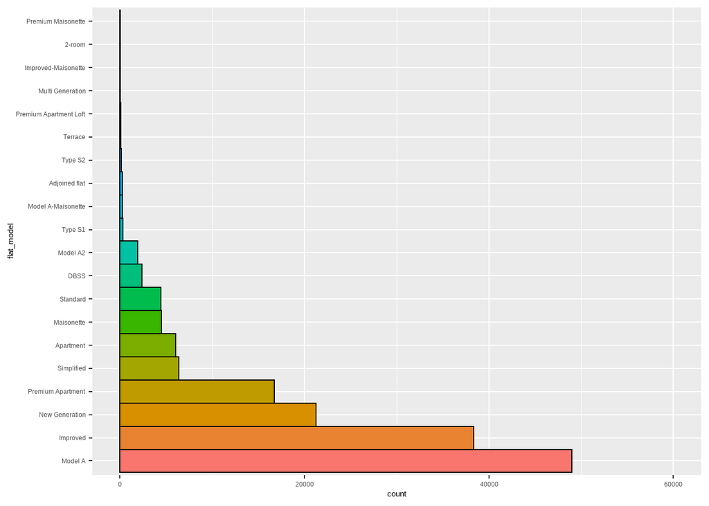

```r
p <- ggplot(data, aes(x = fct_infreq(flat_model), fill = fct_infreq(flat_model))) +
  geom_bar(width = 1, colour = "black", show.legend = FALSE) +
  xlab("flat_model")

p + coord_flip() + scale_y_continuous(limit = c(0, 60000))
```

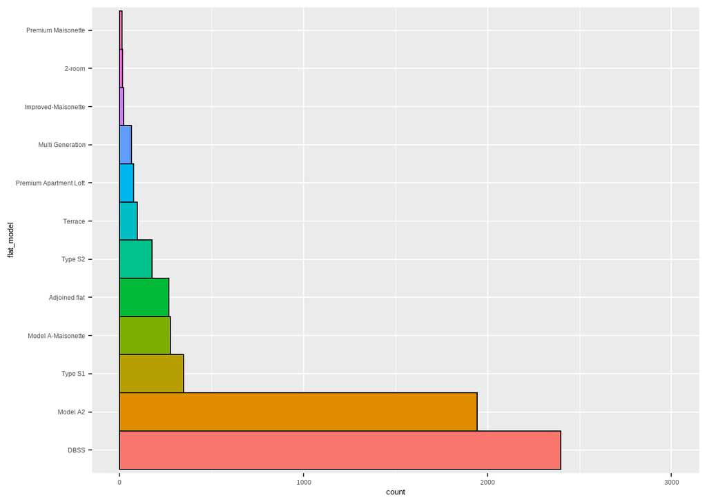

```r
# Zoom in
data_filter <- data %>%
  group_by(flat_model) %>%
  filter(n() < 3000)

p <- ggplot(data_filter, aes(x = fct_infreq(flat_model), fill = fct_infreq(flat_model))) +
  geom_bar(width = 1, colour = "black", show.legend = FALSE) +
  xlab("flat_model")

p + coord_flip() + scale_y_continuous(limit = c(0, 3000))
```

```r
sort(unique(data$flat_model))
```

```
##  [1] 2-room                 Adjoined flat          Apartment
##  [4] DBSS                   Improved               Improved-Maisonette
##  [7] Maisonette             Model A                Model A-Maisonette
## [10] Model A2               Multi Generation       New Generation
## [13] Premium Apartment      Premium Apartment Loft Premium Maisonette
## [16] Simplified             Standard               Terrace
## [19] Type S1                Type S2
## 20 Levels: 2-room Adjoined flat Apartment DBSS Improved ... Type S2
```

- Definition of flat model:
  1. 2-ROOM
  - A 2-room flexi HDB flat is a compact living space which is ideal for singles or young couples. They usually consist of 1 bedroom and 1 bathroom.
  - https://sg.finance.yahoo.com/news/different-types-hdb-houses-call-020000642.html
  2. ADJOINED FLAT
  - Adjoined flats are two flats converted into a single property by homeowners. They usually consist of 5 or 4 bedrooms.
  - https://sg.finance.yahoo.com/news/different-types-hdb-houses-call-020000642.html
  3. APARTMENT
  4. DBSS
  - Design, Build and Sell Scheme (DBSS) flat offer extras in terms of designs and finishes.
  - https://www.hdb.gov.sg/residential/buying-a-flat/resale/getting-started/types-of-flats
  5. IMPROVED
  - Improved flats (1/2/3/4-room) were introduced in 1966, the 3/4-room having separate WC and shower, they also featured void decks.
  - https://www.teoalida.com/singapore/hdbfloorplans/
  6. IMPROVED-MAISONETTE
  7. MAISONETTE
  8. MODEL A
  - In 1981 were introduced Model A flats: 3-Room (75 sqm), 4-Room (105 sqm), 5-Room (135 sqm), 5-Room Maisonette (139 sqm)
  - https://www.teoalida.com/singapore/hdbfloorplans/
  9. MODEL A-MAISONETTE
  - Model A Maisonettes are HDB flats that have two separate levels. They usually consist of 3 bedrooms and 3 bathrooms.
  - https://sg.finance.yahoo.com/news/different-types-hdb-houses-call-020000642.html
  10. MODEL A2
  - 1994-1998 slab block with 4-Room Model A (100 sqm) and 5-Room Improved (120-123 sqm), some blocks have some smaller units named 4-Room Model A2 (90 sqm), some have different corners with 4-Room and 5-Room units, others have a wing with 2 units of 5-Room
  - https://www.teoalida.com/singapore/hdbfloorplans/
  11. MULTI GENERATION
  - Multi-Generation flats can only be bought by multi-generational families, comprising of a married or courting couple, and one set of parents.
  - https://sg.finance.yahoo.com/news/different-types-hdb-houses-call-020000642.html
  12. NEW GENERATION
  - In 1975 were completed the first New Generation flats: 3-Room (67 / 82 sqm) and 4-Room (92 sqm).
  - https://www.teoalida.com/singapore/hdbfloorplans/
  13. PREMIUM APARTMENT
  - The Executive Apartment is an HDB flat which comes with an additional space that can be used as a study room or a living room. In addition to this, some of the executive apartments even come with a balcony space.
  - https://sg.finance.yahoo.com/news/different-types-hdb-houses-call-020000642.html
  14. PREMIUM APARTMENT LOFT
  - HDB loft units are units that come with two storeys and a high ceiling. The living area is typically much bigger than most HDB units. For those who are familiar with executive maisonettes, HDB loft units are the newer and more ‘evolved’ version of maisonettes.
  - https://www.propertyguru.com.sg/property-guides/hdb-loft-units-2-35594
  15. PREMIUM MAISONETTE
  - Executive Maisonettes are the more premium version of Model A Maisonettes. These units are no longer being built after being replaced by the Executive Condominium (EC) scheme in 1995.
  - https://sg.finance.yahoo.com/news/different-types-hdb-houses-call-020000642.html
  16. SIMPLIFIED
  - In 1984 were introduced Simplified flats, 3-Room (64 sqm), 4-Room (84 sqm).
  - https://www.teoalida.com/singapore/hdbfloorplans/
  17. STANDARD
  - Standard flats (1/2/3/4-room) had WC and shower in same room.
  - https://www.teoalida.com/singapore/hdbfloorplans/
  18. TERRACE
  - Terrace HDB houses were first built in the 1960s when the Housing and Development Board (HDB) hadn’t come into the picture yet. These homes were handled by the Singapore Improvement Trust.
  - https://sg.finance.yahoo.com/news/different-types-hdb-houses-call-020000642.html
  19. TYPE S1
  - Pinnacle @ Duxton, the first 50-storey public housing complex, was launched via BTO in May 2004 and got first residents in December 2009, for HDB anniversary of 50 years in February 2010. Composed by 7 blocks × 44 residential floors × 6 units per floor = 1848 units, it was the biggest BTO project to date. It included 2 levels of skybridges, 2 flat types (S1 4-Room 90-93 sqm and S2 5-room 103-106 sqm), different combinations of bay windows, balconies and planters create 35 distinct flat layouts.
  - https://www.teoalida.com/singapore/hdbfloorplans/
  20. TYPE S2
  - Pinnacle @ Duxton, the first 50-storey public housing complex, was launched via BTO in May 2004 and got first residents in December 2009, for HDB anniversary of 50 years in February 2010. Composed by 7 blocks × 44 residential floors × 6 units per floor = 1848 units, it was the biggest BTO project to date. It included 2 levels of skybridges, 2 flat types (S1 4-Room 90-93 sqm and S2 5-room 103-106 sqm), different combinations of bay windows, balconies and planters create 35 distinct flat layouts.
  - https://www.teoalida.com/singapore/hdbfloorplans/
- Types below are classified as uncommon flat model (refer to https://blog.carousell.com/property/hdb-flat-types-singapore/):
  1. Maisonette
  2. Terrace
  3. Adjoined flat
- regroup flat model based on findings above

```r
data$new_flat_model <- ifelse (data$flat_model %in% c("Improved","Model A","Model A2", "New Generation", "Simplified", "Standard",
                                                      "Type S1", "Type S2"), "Flat",
                       ifelse (grepl("Apartment", data$flat_model), "Apartment",
                               ifelse (grepl("Maisonette", data$flat_model), "Maisonette",
                                                       as.character(data$flat_model))))

head(data)
```

```
##   year month       town flat_type block       street_name storey_range
## 1 2015    01 ANG MO KIO    3 ROOM   174  ANG MO KIO AVE 4     07 TO 09
## 2 2015    01 ANG MO KIO    3 ROOM   541 ANG MO KIO AVE 10     01 TO 03
## 3 2015    01 ANG MO KIO    3 ROOM   163  ANG MO KIO AVE 4     01 TO 03
## 4 2015    01 ANG MO KIO    3 ROOM   446 ANG MO KIO AVE 10     01 TO 03
## 5 2015    01 ANG MO KIO    3 ROOM   557 ANG MO KIO AVE 10     07 TO 09
## 6 2015    01 ANG MO KIO    3 ROOM   603  ANG MO KIO AVE 5     07 TO 09
##   floor_area_sqm     flat_model lease_commence_date remaining_lease
## 1             60       Improved                1986              70
## 2             68 New Generation                1981              65
## 3             69 New Generation                1980              64
## 4             68 New Generation                1979              63
## 5             68 New Generation                1980              64
## 6             67 New Generation                1980              64
##   resale_price int_year     region floor_area_sqm_bins price_per_sqm
## 1       255000     2015 North-East             50 - 70       4250.00
## 2       275000     2015 North-East             50 - 70       4044.12
## 3       285000     2015 North-East             50 - 70       4130.43
## 4       290000     2015 North-East             50 - 70       4264.71
## 5       290000     2015 North-East             50 - 70       4264.71
## 6       290000     2015 North-East             50 - 70       4328.36
##   new_flat_model
## 1           Flat
## 2           Flat
## 3           Flat
## 4           Flat
## 5           Flat
## 6           Flat
```

```r
head(data$new_flat_model)
```

```
## [1] "Flat" "Flat" "Flat" "Flat" "Flat" "Flat"
```

```r
tail(data$new_flat_model)
```

```
## [1] "Maisonette"       "Multi Generation" "Multi Generation" "Multi Generation"
## [5] "Multi Generation" "Multi Generation"
```

```r
str(data$new_flat_model)
```

```
##  chr [1:152455] "Flat" "Flat" "Flat" "Flat" "Flat" "Flat" "Flat" "Flat" ...
```

```r
data$new_flat_model <- as.factor(data$new_flat_model)

str(data$new_flat_model)
```

```
##  Factor w/ 8 levels "2-room","Adjoined flat",..: 5 5 5 5 5 5 5 5 5 5 ...
```

```r
sort(summary(data$new_flat_model))
```

```
##           2-room Multi Generation          Terrace    Adjoined flat
##               15               65               96              268
##             DBSS       Maisonette        Apartment             Flat
##             2397             4827            22866           121921
```

- exploration by plotting

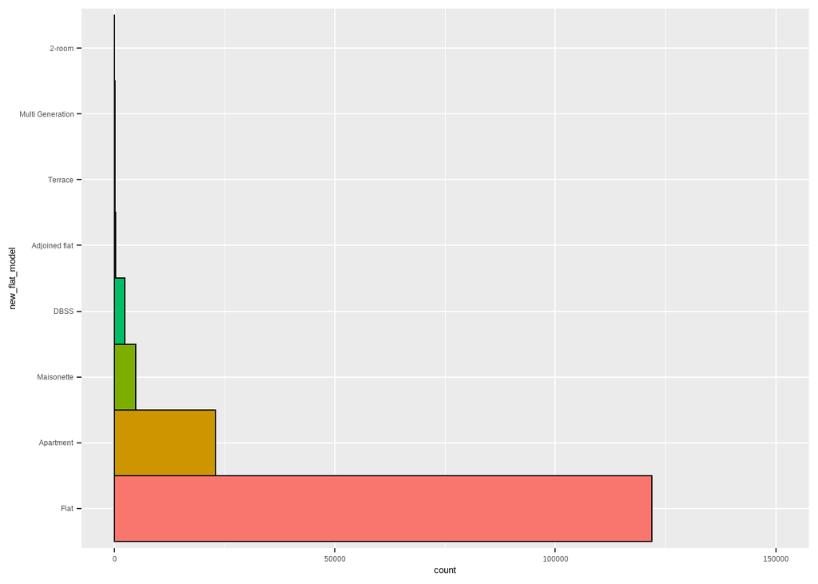

```r
p <- ggplot(data, aes(x = fct_infreq(new_flat_model), fill = fct_infreq(new_flat_model))) +
  geom_bar(width = 1, colour = "black", show.legend = FALSE) +
  xlab("new_flat_model")

p + coord_flip() + scale_y_continuous(limit = c(0, 150000))
```

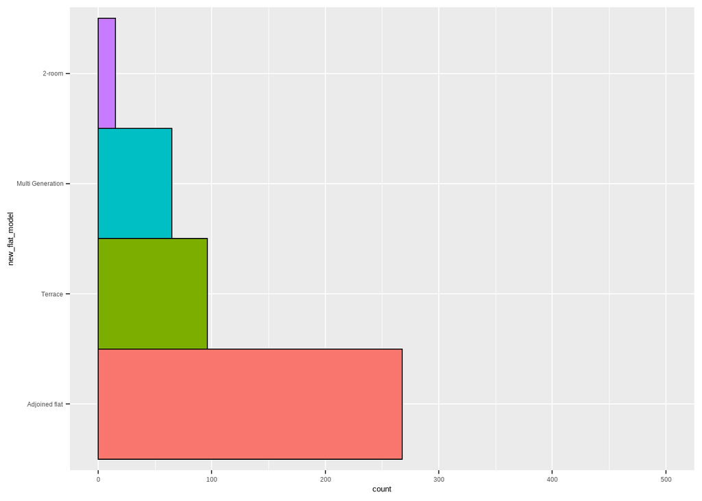

```r
# Zoom in
data_filter <- data %>%
  group_by(new_flat_model) %>%
  filter(n() < 500)

p <- ggplot(data_filter, aes(x = fct_infreq(new_flat_model), fill = fct_infreq(new_flat_model))) +
  geom_bar(width = 1, colour = "black", show.legend = FALSE) +
  xlab("new_flat_model")

p + coord_flip() + scale_y_continuous(limit = c(0, 500))
```

- Flat type HDB has the highest transaction records, more than 100,000 rows
- 2-ROOM type HDB has the lowest transaction records, less than 50 rows

### 9. lease_commence_date

```r
head(data$lease_commence_date)
```

```
## [1] 1986 1981 1980 1979 1980 1980
```

```r
tail(data$lease_commence_date)
```

```
## [1] 1987 1987 1987 1987 1987 1987
```

```r
str(data$lease_commence_date)
```

```
##  int [1:152455] 1986 1981 1980 1979 1980 1980 1980 1981 1978 1985 ...
```

```r
unique(sort(data$lease_commence_date))
```

```
##  [1] 1966 1967 1968 1969 1970 1971 1972 1973 1974 1975 1976 1977 1978 1979 1980
## [16] 1981 1982 1983 1984 1985 1986 1987 1988 1989 1990 1991 1992 1993 1994 1995
## [31] 1996 1997 1998 1999 2000 2001 2002 2003 2004 2005 2006 2007 2008 2009 2010
## [46] 2011 2012 2013 2014 2015 2016 2017 2018 2019
```

```r
data %>% summarise(na = sum(is.na(lease_commence_date)))
```

```
##   na
## 1  0
```

```r
summary(data$lease_commence_date)
```

```
##    Min. 1st Qu.  Median    Mean 3rd Qu.    Max.
##    1966    1984    1993    1994    2003    2019
```

```r
# check whether remaining lease is calculated correctly
data %>%
  filter(!is.na(remaining_lease) && remaining_lease != (99 - (data$int_year - data$lease_commence_date))) %>%
  select(remaining_lease)
```

```
## [1] remaining_lease
## <0 rows> (or 0-length row.names)
```

- there’s no missing value

### 10. resale_price

```r
head(data$resale_price)
```

```
## [1] 255000 275000 285000 290000 290000 290000
```

```r
tail(data$resale_price)
```

```
## [1] 755000 860000 838000 860000 760000 865000
```

```r
str(data$resale_price)
```

```
##  num [1:152455] 255000 275000 285000 290000 290000 ...
```

```r
data %>% summarise(na = sum(is.na(resale_price)))
```

```
##   na
## 1  0
```

```r
summary(data$resale_price)
```

```
##    Min. 1st Qu.  Median    Mean 3rd Qu.    Max.
##  140000  343000  420888  453455  530000 1360000
```

- there’s no missing value
- exploration by plotting

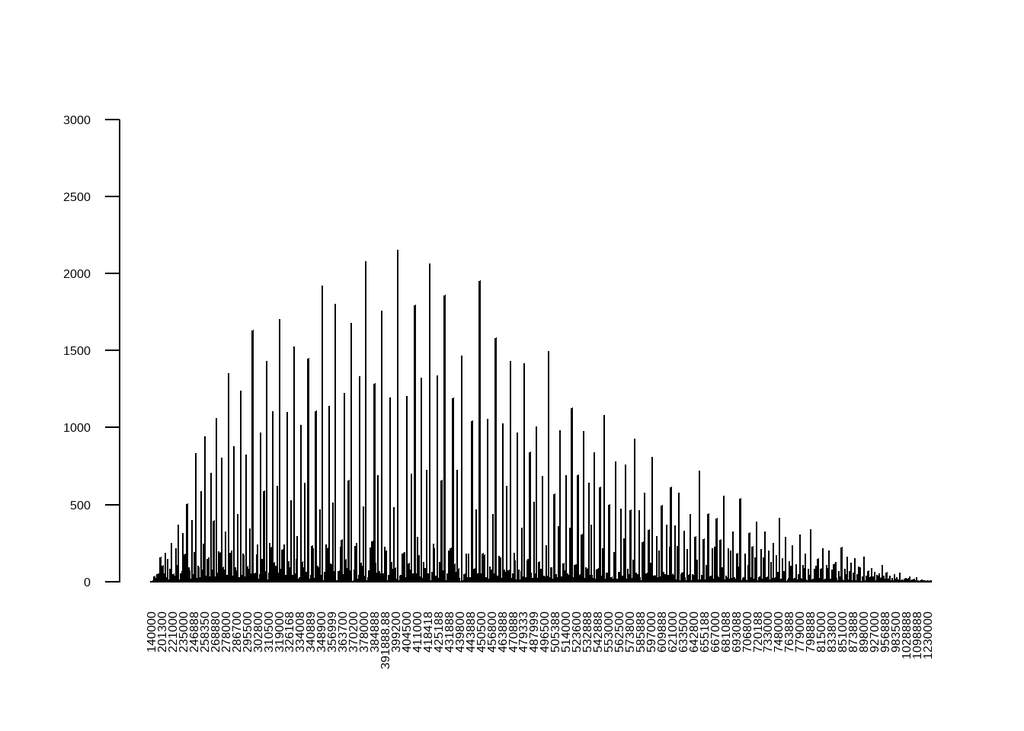

```r
barplot(table(data$resale_price), ylim=c(0,3000), las = 2)
```

- binning

```r
summary(data$resale_price)
```

```
##    Min. 1st Qu.  Median    Mean 3rd Qu.    Max.
##  140000  343000  420888  453455  530000 1360000
```

```r
max(data$resale_price) -  min(data$resale_price)
```

```
## [1] 1220000
```

```r
lower_boundary <- c(seq(79000, 1360000, by=61000))
upper_boundary <- c(seq(140000, 1421000, by=61000))
lower_boundary
```

```
##  [1]   79000  140000  201000  262000  323000  384000  445000  506000  567000
## [10]  628000  689000  750000  811000  872000  933000  994000 1055000 1116000
## [19] 1177000 1238000 1299000 1360000
```

```r
upper_boundary
```

```
##  [1]  140000  201000  262000  323000  384000  445000  506000  567000  628000
## [10]  689000  750000  811000  872000  933000  994000 1055000 1116000 1177000
## [19] 1238000 1299000 1360000 1421000
```

```r
bin_label <- c(paste(paste(lower_boundary, "-"),upper_boundary))
bin_label
```

```
##  [1] "79000 - 140000"    "140000 - 201000"   "201000 - 262000"
##  [4] "262000 - 323000"   "323000 - 384000"   "384000 - 445000"
##  [7] "445000 - 506000"   "506000 - 567000"   "567000 - 628000"
## [10] "628000 - 689000"   "689000 - 750000"   "750000 - 811000"
## [13] "811000 - 872000"   "872000 - 933000"   "933000 - 994000"
## [16] "994000 - 1055000"  "1055000 - 1116000" "1116000 - 1177000"
## [19] "1177000 - 1238000" "1238000 - 1299000" "1299000 - 1360000"
## [22] "1360000 - 1421000"
```

```r
data$resale_price_bins <- cut(data$resale_price, breaks=c(seq(79000, 1421000, by=61000)), labels=bin_label)

data %>% select(resale_price, resale_price_bins) %>% head()
```

```
##   resale_price resale_price_bins
## 1       255000   201000 - 262000
## 2       275000   262000 - 323000
## 3       285000   262000 - 323000
## 4       290000   262000 - 323000
## 5       290000   262000 - 323000
## 6       290000   262000 - 323000
```

```r
str(data$resale_price_bins)
```

```
##  Factor w/ 22 levels "79000 - 140000",..: 3 4 4 4 4 4 4 4 4 4 ...
```

```r
summary(data$resale_price_bins)
```

```
##    79000 - 140000   140000 - 201000   201000 - 262000   262000 - 323000
##                 2               466              7415             22094
##   323000 - 384000   384000 - 445000   445000 - 506000   506000 - 567000
##             27227             30168             21038             13851
##   567000 - 628000   628000 - 689000   689000 - 750000   750000 - 811000
##              9578              7032              5339              3213
##   811000 - 872000   872000 - 933000   933000 - 994000  994000 - 1055000
##              2398              1317               757               313
## 1055000 - 1116000 1116000 - 1177000 1177000 - 1238000 1238000 - 1299000
##               123                71                37                15
## 1299000 - 1360000 1360000 - 1421000
##                 1                 0
```

```r
data %>% filter(is.na(resale_price_bins)) %>% select(resale_price, resale_price_bins) %>% head()
```

```
## [1] resale_price      resale_price_bins
## <0 rows> (or 0-length row.names)
```

- exploration by plotting

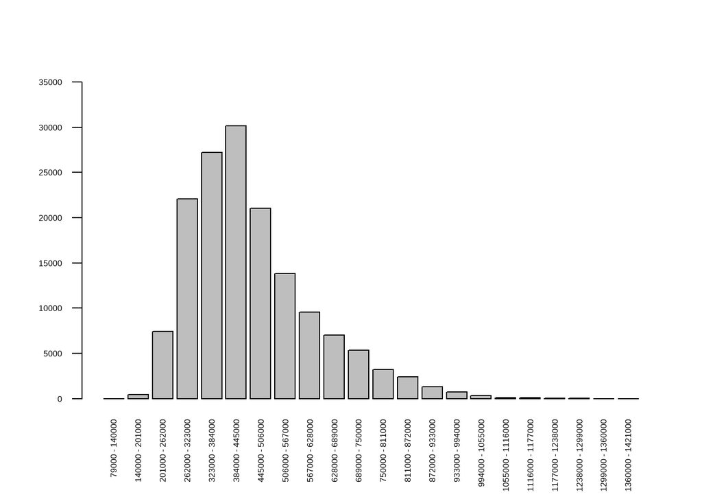

```r
barplot(table(data$resale_price_bins), ylim=c(0,35000), las = 2)
```